# More Methods for Classification – Project Related

In addition to CART, SVM, Random Forest, GBM, Naive Bayes, etc., there are several other methods for classification, including both linear and nonlinear models:

1. **Logistic Regression** : Linear model for binary or multiclass classification.
2. **Lasso / Ridge Regression** : Linear models with regularization to prevent overfitting.
3. **Neural Networks**: Flexible nonlinear models capable of capturing complex relationships.
4. **K-Nearest Neighbors (KNN)**
5. **MARS**
6. **Other methods** – ...

Example: In 'mlbench' package, there is 'Sonar' data. The goal is to classify sonar signals as either rock (R) or mine (M) based on energy patterns returned by sonar pulses.

# Source: UCI Machine Learning Repository.

Please build predictive models using different methods.

```r
# Load libraries
library(caret)
library(glmnet)
library(pROC)
library(neuralnet)
library(tidyverse)
```

```r
library(mlbench)   # Sonar dataset

data(Sonar)
#head(Sonar)
#str(Sonar)

#Response: Class
#V1- V60: Predictors
```

```r
str(Sonar)
```

```
'data.frame':	208 obs. of  61 variables:
 $ V1   : num  0.02 0.0453 0.0262 0.01 0.0762 0.0286 0.0317 0.0519 0.0223 0.0164 ...
 $ V2   : num  0.0371 0.0523 0.0582 0.0171 0.0666 0.0453 0.0956 0.0548 0.0375 0.0173 ...
 $ V3   : num  0.0428 0.0843 0.1099 0.0623 0.0481 ...
 $ V4   : num  0.0207 0.0689 0.1083 0.0205 0.0394 ...
 $ V5   : num  0.0954 0.1183 0.0974 0.0205 0.059 ...
 $ V6   : num  0.0986 0.2583 0.228 0.0368 0.0649 ...
 $ V7   : num  0.154 0.216 0.243 0.11 0.121 ...
 $ V8   : num  0.16 0.348 0.377 0.128 0.247 ...
 $ V9   : num  0.3109 0.3337 0.5598 0.0598 0.3564 ...
 $ V10  : num  0.211 0.287 0.619 0.126 0.446 ...
 $ V11  : num  0.1609 0.4918 0.6333 0.0881 0.4152 ...
 $ V12  : num  0.158 0.655 0.706 0.199 0.395 ...
 $ V13  : num  0.2238 0.6919 0.5544 0.0184 0.4256 ...
 $ V14  : num  0.0645 0.7797 0.532 0.2261 0.4135 ...
```

[output cut: 47 more lines]

```r
#Split the data into train set and test set
set.seed(252)

index = createDataPartition(Sonar$Class, p = 0.75, list = FALSE)
train.dat = Sonar[index,]
test.dat =   Sonar[-index,]
```

```r
# Logistic regression with train function  (Issues: #Sonar dataset is high-dimensional relative to the sample size)

glm.fit = train(
  Class ~ ., data = train.dat,
  trControl = trainControl(method = "cv", number = 5),
  method = "glm",
  family = "binomial"            #logistic regression
)

#Sonar dataset is high-dimensional relative to the sample size
```

```r
library(car)
vif = vif(fit.glm0)
round(vif, 3)

step(fit.glm0, track=0)
```

**V1**

466.117

**V2**

381.757

**V3**

240.628

**V4**

347.134

**V5**

464.429

**V6**

352.25

**V7**

631.121

**V8**

812.871

**V9**

1049.821

**V10**

285.683

**V11**

243.944

**V12**

591.879

**V13**

1227.935

**V14**

851.264

**V15**

528.31

**V16**

1803

**V17**

4396.071

**V18**

1381.894

**V19**

687.287

**V20**

1427.436

**V21**

3876.745

**V22**

8143.398

**V23**

6200.997

**V24**

782.288

**V25**

1040.113

**V26**

621.667

**V27**

951.435

**V28**

1003.249

**V29**

992.77

**V30**

1105.053

**V31**

1930.129

**V32**

823.009

**V33**

375.548

**V34**

822.747

**V35**

1176.935

**V36**

1269.349

**V37**

851.967

**V38**

2839.642

**V39**

383.441

**V40**

456.031

**V41**

1066.527

**V42**

1685.517

**V43**

1014.452

**V44**

707.946

**V45**

717.018

**V46**

473.605

**V47**

514.496

**V48**

211.664

**V49**

291.584

**V50**

95.856

**V51**

91.819

**V52**

114.707

**V53**

59.023

**V54**

121.001

**V55**

69.726

**V56**

267.271

**V57**

103.97

**V58**

189.061

**V59**

1160.62

**V60**

1609.398

```
Start:  AIC=122
as.factor(Class) ~ V1 + V2 + V3 + V4 + V5 + V6 + V7 + V8 + V9 +
    V10 + V11 + V12 + V13 + V14 + V15 + V16 + V17 + V18 + V19 +
    V20 + V21 + V22 + V23 + V24 + V25 + V26 + V27 + V28 + V29 +
    V30 + V31 + V32 + V33 + V34 + V35 + V36 + V37 + V38 + V39 +
    V40 + V41 + V42 + V43 + V44 + V45 + V46 + V47 + V48 + V49 +
    V50 + V51 + V52 + V53 + V54 + V55 + V56 + V57 + V58 + V59 +
    V60
```

[output not shown]

[output cut: 185 more lines]

[output not shown]

```
       Df   Deviance AIC
- V43   1 8.3774e-09 120
- V42   1 8.3786e-09 120
- V44   1 8.3825e-09 120
- V55   1 8.3867e-09 120
- V19   1 8.4026e-09 120
- V11   1 8.4074e-09 120
- V9    1 8.4122e-09 120
- V54   1 8.4200e-09 120
- V33   1 8.4247e-09 120
- V16   1 8.4264e-09 120
- V53   1 8.4596e-09 120
- V8    1 8.4615e-09 120
- V57   1 8.4652e-09 120
- V5    1 8.4815e-09 120
- V14   1 8.4833e-09 120
- V34   1 8.5127e-09 120
- V51   1 8.5271e-09 120
- V47   1 8.5387e-09 120
- V6    1 8.5454e-09 120
- V20   1 8.5589e-09 120
- V26   1 8.5616e-09 120
- V60   1 8.5673e-09 120
- V59   1 8.5724e-09 120
- V41   1 8.5907e-09 120
- V49   1 8.6006e-09 120
- V48   1 8.6013e-09 120
- V38   1 8.6181e-09 120
- V45   1 8.6336e-09 120
- V10   1 8.6666e-09 120
- V7    1 8.7118e-09 120
- V46   1 8.7409e-09 120
- V25   1 8.7886e-09 120
- V2    1 8.8364e-09 120
- V18   1 8.8458e-09 120
- V27   1 8.8923e-09 120
- V1    1 8.8985e-09 120
- V50   1 8.9970e-09 120
- V39   1 9.0206e-09 120
- V15   1 9.0503e-09 120
- V35   1 9.1369e-09 120
- V37   1 9.1566e-09 120
- V58   1 9.1920e-09 120
- V56   1 9.3574e-09 120
- V21   1 9.3697e-09 120
- V29   1 9.4389e-09 120
- V23   1 9.4520e-09 120
- V32   1 9.4718e-09 120
- V40   1 9.4835e-09 120
- V17   1 9.5586e-09 120
- V24   1 9.5957e-09 120
- V28   1 9.6139e-09 120
- V4    1 9.6425e-09 120
- V30   1 9.8338e-09 120
- V22   1 9.8863e-09 120
- V52   1 1.0046e-08 120
- V36   1 1.0496e-08 120
- V13   1 1.0778e-08 120
- V12   1 1.1349e-08 120
- V31   1 1.2158e-08 120
- V3    1 1.3128e-08 120
<none>    8.3610e-09 122
```

```
Step:  AIC=120
as.factor(Class) ~ V1 + V2 + V3 + V4 + V5 + V6 + V7 + V8 + V9 +
    V10 + V11 + V12 + V13 + V14 + V15 + V16 + V17 + V18 + V19 +
    V20 + V21 + V22 + V23 + V24 + V25 + V26 + V27 + V28 + V29 +
    V30 + V31 + V32 + V33 + V34 + V35 + V36 + V37 + V38 + V39 +
    V40 + V41 + V42 + V44 + V45 + V46 + V47 + V48 + V49 + V50 +
    V51 + V52 + V53 + V54 + V55 + V56 + V57 + V58 + V59 + V60
```

[output not shown]

[output cut: 181 more lines]

[output not shown]

```
       Df   Deviance AIC
- V44   1 8.3895e-09 118
- V19   1 8.4070e-09 118
- V55   1 8.4109e-09 118
- V42   1 8.4208e-09 118
- V11   1 8.4255e-09 118
- V33   1 8.4390e-09 118
- V54   1 8.4449e-09 118
- V16   1 8.4515e-09 118
- V9    1 8.4536e-09 118
- V53   1 8.4875e-09 118
- V57   1 8.4965e-09 118
- V14   1 8.4981e-09 118
- V8    1 8.4990e-09 118
- V51   1 8.5283e-09 118
- V5    1 8.5415e-09 118
- V47   1 8.5485e-09 118
- V6    1 8.5580e-09 118
- V34   1 8.5585e-09 118
- V59   1 8.5626e-09 118
- V20   1 8.5844e-09 118
- V49   1 8.5965e-09 118
- V60   1 8.6174e-09 118
- V48   1 8.6299e-09 118
- V38   1 8.6617e-09 118
- V41   1 8.6827e-09 118
- V10   1 8.6972e-09 118
- V26   1 8.7180e-09 118
- V45   1 8.7212e-09 118
- V7    1 8.7402e-09 118
- V46   1 8.7578e-09 118
- V18   1 8.8405e-09 118
- V2    1 8.8584e-09 118
- V25   1 8.9288e-09 118
- V1    1 9.0362e-09 118
- V39   1 9.0468e-09 118
- V27   1 9.0504e-09 118
- V50   1 9.0989e-09 118
- V15   1 9.1214e-09 118
- V35   1 9.1499e-09 118
- V37   1 9.2001e-09 118
- V58   1 9.2361e-09 118
- V56   1 9.3798e-09 118
- V21   1 9.3870e-09 118
- V29   1 9.4610e-09 118
- V23   1 9.4909e-09 118
- V17   1 9.5644e-09 118
- V24   1 9.6047e-09 118
- V32   1 9.6169e-09 118
- V28   1 9.6409e-09 118
- V4    1 9.6528e-09 118
- V22   1 9.8417e-09 118
- V40   1 9.9702e-09 118
- V52   1 1.0309e-08 118
- V30   1 1.0344e-08 118
- V36   1 1.0519e-08 118
- V13   1 1.0876e-08 118
- V12   1 1.1364e-08 118
- V31   1 1.2337e-08 118
- V3    1 1.3171e-08 118
<none>    8.3774e-09 120
```

```
Step:  AIC=118
as.factor(Class) ~ V1 + V2 + V3 + V4 + V5 + V6 + V7 + V8 + V9 +
    V10 + V11 + V12 + V13 + V14 + V15 + V16 + V17 + V18 + V19 +
    V20 + V21 + V22 + V23 + V24 + V25 + V26 + V27 + V28 + V29 +
    V30 + V31 + V32 + V33 + V34 + V35 + V36 + V37 + V38 + V39 +
    V40 + V41 + V42 + V45 + V46 + V47 + V48 + V49 + V50 + V51 +
    V52 + V53 + V54 + V55 + V56 + V57 + V58 + V59 + V60
```

[output not shown]

[output cut: 177 more lines]

[output not shown]

```
       Df   Deviance AIC
- V19   1 8.4211e-09 116
- V55   1 8.4333e-09 116
- V11   1 8.4374e-09 116
- V33   1 8.4508e-09 116
- V16   1 8.4740e-09 116
- V9    1 8.4832e-09 116
- V57   1 8.4971e-09 116
- V53   1 8.5052e-09 116
- V42   1 8.5080e-09 116
- V54   1 8.5080e-09 116
- V8    1 8.5119e-09 116
- V14   1 8.5274e-09 116
- V34   1 8.5587e-09 116
- V5    1 8.5598e-09 116
- V51   1 8.5649e-09 116
- V47   1 8.5715e-09 116
- V59   1 8.5869e-09 116
- V6    1 8.5938e-09 116
- V20   1 8.6037e-09 116
- V48   1 8.6377e-09 116
- V60   1 8.6480e-09 116
- V49   1 8.6709e-09 116
- V41   1 8.6978e-09 116
- V10   1 8.7032e-09 116
- V38   1 8.7100e-09 116
- V26   1 8.7277e-09 116
- V46   1 8.7746e-09 116
- V7    1 8.8077e-09 116
- V18   1 8.8517e-09 116
- V2    1 8.8851e-09 116
- V25   1 8.9600e-09 116
- V39   1 9.0471e-09 116
- V27   1 9.0987e-09 116
- V50   1 9.1128e-09 116
- V15   1 9.1233e-09 116
- V1    1 9.2019e-09 116
- V35   1 9.2190e-09 116
- V37   1 9.2270e-09 116
- V58   1 9.3032e-09 116
- V45   1 9.3355e-09 116
- V56   1 9.3786e-09 116
- V21   1 9.4248e-09 116
- V29   1 9.4759e-09 116
- V23   1 9.5408e-09 116
- V32   1 9.6253e-09 116
- V24   1 9.6508e-09 116
- V17   1 9.7280e-09 116
- V28   1 9.7490e-09 116
- V22   1 9.8767e-09 116
- V4    1 9.9151e-09 116
- V40   1 1.0029e-08 116
- V30   1 1.0387e-08 116
- V52   1 1.0415e-08 116
- V36   1 1.0550e-08 116
- V13   1 1.0911e-08 116
- V12   1 1.1367e-08 116
- V31   1 1.2764e-08 116
- V3    1 1.3241e-08 116
<none>    8.3895e-09 118
```

```
Step:  AIC=116
as.factor(Class) ~ V1 + V2 + V3 + V4 + V5 + V6 + V7 + V8 + V9 +
    V10 + V11 + V12 + V13 + V14 + V15 + V16 + V17 + V18 + V20 +
    V21 + V22 + V23 + V24 + V25 + V26 + V27 + V28 + V29 + V30 +
    V31 + V32 + V33 + V34 + V35 + V36 + V37 + V38 + V39 + V40 +
    V41 + V42 + V45 + V46 + V47 + V48 + V49 + V50 + V51 + V52 +
    V53 + V54 + V55 + V56 + V57 + V58 + V59 + V60
```

[output not shown]

[output cut: 173 more lines]

[output not shown]

```
       Df   Deviance AIC
- V11   1 8.4750e-09 114
- V55   1 8.4825e-09 114
- V33   1 8.5100e-09 114
- V53   1 8.5340e-09 114
- V9    1 8.5413e-09 114
- V16   1 8.5432e-09 114
- V54   1 8.5487e-09 114
- V57   1 8.5511e-09 114
- V14   1 8.5543e-09 114
- V42   1 8.5665e-09 114
- V34   1 8.5777e-09 114
- V51   1 8.5839e-09 114
- V47   1 8.5856e-09 114
- V8    1 8.6026e-09 114
- V59   1 8.6164e-09 114
- V5    1 8.6456e-09 114
- V6    1 8.6456e-09 114
- V48   1 8.6680e-09 114
- V60   1 8.6821e-09 114
- V26   1 8.7076e-09 114
- V38   1 8.7203e-09 114
- V41   1 8.7479e-09 114
- V49   1 8.7593e-09 114
- V10   1 8.7753e-09 114
- V46   1 8.7897e-09 114
- V7    1 8.8795e-09 114
- V25   1 8.8908e-09 114
- V2    1 8.9754e-09 114
- V18   1 9.0304e-09 114
- V39   1 9.0665e-09 114
- V27   1 9.1106e-09 114
- V35   1 9.1668e-09 114
- V20   1 9.2050e-09 114
- V50   1 9.2094e-09 114
- V1    1 9.2368e-09 114
- V15   1 9.2870e-09 114
- V37   1 9.3220e-09 114
- V45   1 9.3545e-09 114
- V56   1 9.3753e-09 114
- V29   1 9.4167e-09 114
- V23   1 9.4808e-09 114
- V24   1 9.7348e-09 114
- V28   1 9.7486e-09 114
- V17   1 9.7490e-09 114
- V32   1 9.7834e-09 114
- V58   1 9.9490e-09 114
- V4    1 9.9633e-09 114
- V22   1 1.0008e-08 114
- V40   1 1.0131e-08 114
- V30   1 1.0260e-08 114
- V36   1 1.0537e-08 114
- V52   1 1.0545e-08 114
- V21   1 1.0690e-08 114
- V13   1 1.0866e-08 114
- V12   1 1.1958e-08 114
- V31   1 1.2835e-08 114
- V3    1 1.3346e-08 114
<none>    8.4211e-09 116
```

```
Step:  AIC=114
as.factor(Class) ~ V1 + V2 + V3 + V4 + V5 + V6 + V7 + V8 + V9 +
    V10 + V12 + V13 + V14 + V15 + V16 + V17 + V18 + V20 + V21 +
    V22 + V23 + V24 + V25 + V26 + V27 + V28 + V29 + V30 + V31 +
    V32 + V33 + V34 + V35 + V36 + V37 + V38 + V39 + V40 + V41 +
    V42 + V45 + V46 + V47 + V48 + V49 + V50 + V51 + V52 + V53 +
    V54 + V55 + V56 + V57 + V58 + V59 + V60
```

[output not shown]

[output cut: 169 more lines]

[output not shown]

```
       Df   Deviance AIC
- V33   1 8.5497e-09 112
- V54   1 8.5656e-09 112
- V9    1 8.5717e-09 112
- V16   1 8.5752e-09 112
- V55   1 8.5876e-09 112
- V42   1 8.5949e-09 112
- V34   1 8.6001e-09 112
- V57   1 8.6049e-09 112
- V8    1 8.6076e-09 112
- V14   1 8.6252e-09 112
- V53   1 8.6523e-09 112
- V51   1 8.6566e-09 112
- V59   1 8.6586e-09 112
- V47   1 8.6643e-09 112
- V5    1 8.6788e-09 112
- V60   1 8.7020e-09 112
- V48   1 8.7506e-09 112
- V38   1 8.7583e-09 112
- V26   1 8.7605e-09 112
- V6    1 8.7875e-09 112
- V49   1 8.8243e-09 112
- V46   1 8.8334e-09 112
- V10   1 8.9031e-09 112
- V41   1 8.9141e-09 112
- V25   1 8.9220e-09 112
- V2    1 9.0393e-09 112
- V39   1 9.1138e-09 112
- V18   1 9.1220e-09 112
- V27   1 9.1228e-09 112
- V7    1 9.1706e-09 112
- V1    1 9.2746e-09 112
- V37   1 9.3540e-09 112
- V50   1 9.3636e-09 112
- V20   1 9.3731e-09 112
- V15   1 9.3809e-09 112
- V35   1 9.4021e-09 112
- V45   1 9.4132e-09 112
- V29   1 9.4742e-09 112
- V56   1 9.4911e-09 112
- V23   1 9.5506e-09 112
- V28   1 9.7613e-09 112
- V32   1 9.8064e-09 112
- V24   1 9.8339e-09 112
- V17   1 9.8595e-09 112
- V58   1 9.9732e-09 112
- V4    1 9.9937e-09 112
- V22   1 1.0102e-08 112
- V40   1 1.0192e-08 112
- V52   1 1.0614e-08 112
- V30   1 1.0643e-08 112
- V21   1 1.0730e-08 112
- V36   1 1.0816e-08 112
- V13   1 1.1202e-08 112
- V31   1 1.3531e-08 112
- V3    1 1.3745e-08 112
- V12   1 1.6649e-08 112
<none>    8.4750e-09 114
```

```
Step:  AIC=112
as.factor(Class) ~ V1 + V2 + V3 + V4 + V5 + V6 + V7 + V8 + V9 +
    V10 + V12 + V13 + V14 + V15 + V16 + V17 + V18 + V20 + V21 +
    V22 + V23 + V24 + V25 + V26 + V27 + V28 + V29 + V30 + V31 +
    V32 + V34 + V35 + V36 + V37 + V38 + V39 + V40 + V41 + V42 +
    V45 + V46 + V47 + V48 + V49 + V50 + V51 + V52 + V53 + V54 +
    V55 + V56 + V57 + V58 + V59 + V60
```

[output not shown]

[output cut: 165 more lines]

[output not shown]

```
       Df   Deviance AIC
- V54   1 8.5934e-09 110
- V55   1 8.6023e-09 110
- V14   1 8.6212e-09 110
- V9    1 8.6314e-09 110
- V57   1 8.6445e-09 110
- V53   1 8.6468e-09 110
- V16   1 8.6636e-09 110
- V42   1 8.6652e-09 110
- V5    1 8.6715e-09 110
- V59   1 8.6715e-09 110
- V8    1 8.6850e-09 110
- V51   1 8.6904e-09 110
- V60   1 8.7112e-09 110
- V38   1 8.7607e-09 110
- V47   1 8.7642e-09 110
- V26   1 8.7658e-09 110
- V6    1 8.8550e-09 110
- V49   1 8.8556e-09 110
- V46   1 8.8616e-09 110
- V48   1 8.9307e-09 110
- V34   1 8.9440e-09 110
- V25   1 8.9619e-09 110
- V41   1 8.9861e-09 110
- V10   1 9.0733e-09 110
- V27   1 9.1147e-09 110
- V18   1 9.1218e-09 110
- V39   1 9.1307e-09 110
- V2    1 9.2119e-09 110
- V7    1 9.2774e-09 110
- V1    1 9.3244e-09 110
- V20   1 9.3628e-09 110
- V15   1 9.4399e-09 110
- V35   1 9.5008e-09 110
- V45   1 9.5112e-09 110
- V56   1 9.5279e-09 110
- V50   1 9.6007e-09 110
- V23   1 9.6052e-09 110
- V29   1 9.6971e-09 110
- V37   1 9.7157e-09 110
- V28   1 9.7917e-09 110
- V24   1 9.8108e-09 110
- V17   1 9.8376e-09 110
- V4    1 9.9959e-09 110
- V58   1 1.0117e-08 110
- V40   1 1.0217e-08 110
- V22   1 1.0224e-08 110
- V32   1 1.0524e-08 110
- V52   1 1.0637e-08 110
- V21   1 1.0729e-08 110
- V30   1 1.0919e-08 110
- V36   1 1.1317e-08 110
- V13   1 1.1339e-08 110
- V31   1 1.3788e-08 110
- V3    1 1.3813e-08 110
- V12   1 1.8062e-08 110
<none>    8.5497e-09 112
```

```
Step:  AIC=110
as.factor(Class) ~ V1 + V2 + V3 + V4 + V5 + V6 + V7 + V8 + V9 +
    V10 + V12 + V13 + V14 + V15 + V16 + V17 + V18 + V20 + V21 +
    V22 + V23 + V24 + V25 + V26 + V27 + V28 + V29 + V30 + V31 +
    V32 + V34 + V35 + V36 + V37 + V38 + V39 + V40 + V41 + V42 +
    V45 + V46 + V47 + V48 + V49 + V50 + V51 + V52 + V53 + V55 +
    V56 + V57 + V58 + V59 + V60
```

[output not shown]

[output cut: 161 more lines]

[output not shown]

```
       Df   Deviance AIC
- V55   1 8.6288e-09 108
- V14   1 8.6556e-09 108
- V9    1 8.6575e-09 108
- V53   1 8.6819e-09 108
- V16   1 8.6923e-09 108
- V8    1 8.6991e-09 108
- V59   1 8.7001e-09 108
- V42   1 8.7041e-09 108
- V5    1 8.7077e-09 108
- V57   1 8.7261e-09 108
- V60   1 8.7286e-09 108
- V51   1 8.7455e-09 108
- V47   1 8.7773e-09 108
- V26   1 8.7993e-09 108
- V38   1 8.8170e-09 108
- V49   1 8.8659e-09 108
- V46   1 8.9732e-09 108
- V34   1 8.9796e-09 108
- V6    1 8.9981e-09 108
- V48   1 9.0128e-09 108
- V41   1 9.0444e-09 108
- V25   1 9.0861e-09 108
- V39   1 9.1502e-09 108
- V18   1 9.1576e-09 108
- V27   1 9.1724e-09 108
- V2    1 9.2459e-09 108
- V7    1 9.3084e-09 108
- V1    1 9.3527e-09 108
- V10   1 9.3696e-09 108
- V20   1 9.3924e-09 108
- V45   1 9.5187e-09 108
- V56   1 9.5649e-09 108
- V35   1 9.6186e-09 108
- V15   1 9.6550e-09 108
- V50   1 9.6801e-09 108
- V23   1 9.7494e-09 108
- V37   1 9.9815e-09 108
- V17   1 1.0009e-08 108
- V28   1 1.0033e-08 108
- V24   1 1.0096e-08 108
- V4    1 1.0215e-08 108
- V40   1 1.0322e-08 108
- V29   1 1.0596e-08 108
- V32   1 1.0698e-08 108
- V58   1 1.0716e-08 108
- V52   1 1.0793e-08 108
- V22   1 1.0947e-08 108
- V21   1 1.1289e-08 108
- V13   1 1.1443e-08 108
- V30   1 1.2167e-08 108
- V36   1 1.2791e-08 108
- V3    1 1.3806e-08 108
- V31   1 1.5156e-08 108
- V12   1 1.8362e-08 108
<none>    8.5934e-09 110
```

```
Step:  AIC=108
as.factor(Class) ~ V1 + V2 + V3 + V4 + V5 + V6 + V7 + V8 + V9 +
    V10 + V12 + V13 + V14 + V15 + V16 + V17 + V18 + V20 + V21 +
    V22 + V23 + V24 + V25 + V26 + V27 + V28 + V29 + V30 + V31 +
    V32 + V34 + V35 + V36 + V37 + V38 + V39 + V40 + V41 + V42 +
    V45 + V46 + V47 + V48 + V49 + V50 + V51 + V52 + V53 + V56 +
    V57 + V58 + V59 + V60
```

[output not shown]

[output cut: 157 more lines]

[output not shown]

```
       Df   Deviance AIC
- V14   1 8.7199e-09 106
- V16   1 8.7281e-09 106
- V9    1 8.7284e-09 106
- V53   1 8.7357e-09 106
- V51   1 8.7464e-09 106
- V5    1 8.7782e-09 106
- V59   1 8.7809e-09 106
- V57   1 8.7839e-09 106
- V8    1 8.7994e-09 106
- V26   1 8.8030e-09 106
- V60   1 8.8091e-09 106
- V47   1 8.8507e-09 106
- V42   1 8.8666e-09 106
- V38   1 8.9391e-09 106
- V49   1 8.9651e-09 106
- V48   1 9.0507e-09 106
- V6    1 9.0611e-09 106
- V46   1 9.1214e-09 106
- V25   1 9.1220e-09 106
- V39   1 9.1651e-09 106
- V27   1 9.1965e-09 106
- V18   1 9.2131e-09 106
- V34   1 9.2432e-09 106
- V41   1 9.3445e-09 106
- V7    1 9.3782e-09 106
- V2    1 9.3943e-09 106
- V1    1 9.4323e-09 106
- V10   1 9.5928e-09 106
- V56   1 9.5969e-09 106
- V20   1 9.6325e-09 106
- V50   1 9.7409e-09 106
- V45   1 9.7636e-09 106
- V15   1 9.8172e-09 106
- V35   1 9.8876e-09 106
- V28   1 1.0056e-08 106
- V17   1 1.0158e-08 106
- V4    1 1.0297e-08 106
- V23   1 1.0303e-08 106
- V24   1 1.0310e-08 106
- V37   1 1.0479e-08 106
- V40   1 1.0543e-08 106
- V29   1 1.0727e-08 106
- V52   1 1.0814e-08 106
- V13   1 1.1446e-08 106
- V21   1 1.1490e-08 106
- V32   1 1.1566e-08 106
- V58   1 1.1707e-08 106
- V22   1 1.1997e-08 106
- V36   1 1.2857e-08 106
- V30   1 1.3085e-08 106
- V3    1 1.3814e-08 106
- V31   1 1.6816e-08 106
- V12   1 1.8817e-08 106
<none>    8.6288e-09 108
```

```
Step:  AIC=106
as.factor(Class) ~ V1 + V2 + V3 + V4 + V5 + V6 + V7 + V8 + V9 +
    V10 + V12 + V13 + V15 + V16 + V17 + V18 + V20 + V21 + V22 +
    V23 + V24 + V25 + V26 + V27 + V28 + V29 + V30 + V31 + V32 +
    V34 + V35 + V36 + V37 + V38 + V39 + V40 + V41 + V42 + V45 +
    V46 + V47 + V48 + V49 + V50 + V51 + V52 + V53 + V56 + V57 +
    V58 + V59 + V60
```

[output not shown]

[output cut: 153 more lines]

[output not shown]

```
       Df   Deviance AIC
- V16   1 8.7560e-09 104
- V51   1 8.7955e-09 104
- V8    1 8.8137e-09 104
- V9    1 8.8155e-09 104
- V26   1 8.8182e-09 104
- V53   1 8.8215e-09 104
- V57   1 8.8549e-09 104
- V47   1 8.8951e-09 104
- V59   1 8.9343e-09 104
- V5    1 8.9358e-09 104
- V42   1 8.9379e-09 104
- V60   1 8.9811e-09 104
- V48   1 9.0109e-09 104
- V6    1 9.0619e-09 104
- V25   1 9.0961e-09 104
- V49   1 9.1813e-09 104
- V27   1 9.2410e-09 104
- V46   1 9.2555e-09 104
- V34   1 9.2851e-09 104
- V41   1 9.3269e-09 104
- V38   1 9.3526e-09 104
- V7    1 9.3908e-09 104
- V2    1 9.4443e-09 104
- V18   1 9.4735e-09 104
- V10   1 9.5323e-09 104
- V1    1 9.7439e-09 104
- V50   1 9.7537e-09 104
- V45   1 9.7808e-09 104
- V56   1 9.8546e-09 104
- V35   1 1.0093e-08 104
- V20   1 1.0095e-08 104
- V23   1 1.0281e-08 104
- V39   1 1.0297e-08 104
- V24   1 1.0312e-08 104
- V28   1 1.0323e-08 104
- V4    1 1.0424e-08 104
- V17   1 1.0672e-08 104
- V29   1 1.0763e-08 104
- V15   1 1.0795e-08 104
- V40   1 1.1045e-08 104
- V52   1 1.1068e-08 104
- V37   1 1.1435e-08 104
- V58   1 1.1740e-08 104
- V22   1 1.1974e-08 104
- V21   1 1.1995e-08 104
- V32   1 1.2233e-08 104
- V13   1 1.2812e-08 104
- V36   1 1.3039e-08 104
- V30   1 1.3382e-08 104
- V3    1 1.4084e-08 104
- V12   1 2.0838e-08 104
- V31   1 2.1845e-08 104
<none>    8.7199e-09 106
```

```
Step:  AIC=104
as.factor(Class) ~ V1 + V2 + V3 + V4 + V5 + V6 + V7 + V8 + V9 +
    V10 + V12 + V13 + V15 + V17 + V18 + V20 + V21 + V22 + V23 +
    V24 + V25 + V26 + V27 + V28 + V29 + V30 + V31 + V32 + V34 +
    V35 + V36 + V37 + V38 + V39 + V40 + V41 + V42 + V45 + V46 +
    V47 + V48 + V49 + V50 + V51 + V52 + V53 + V56 + V57 + V58 +
    V59 + V60
```

[output not shown]

[output cut: 149 more lines]

[output not shown]

```
       Df   Deviance AIC
- V51   1 8.8151e-09 102
- V26   1 8.8436e-09 102
- V9    1 8.8991e-09 102
- V53   1 8.9159e-09 102
- V57   1 8.9206e-09 102
- V47   1 8.9451e-09 102
- V42   1 8.9581e-09 102
- V8    1 8.9878e-09 102
- V48   1 9.0534e-09 102
- V25   1 9.1044e-09 102
- V5    1 9.1451e-09 102
- V49   1 9.2201e-09 102
- V6    1 9.2419e-09 102
- V60   1 9.2809e-09 102
- V27   1 9.3082e-09 102
- V46   1 9.3110e-09 102
- V34   1 9.3125e-09 102
- V59   1 9.3405e-09 102
- V41   1 9.3476e-09 102
- V38   1 9.5108e-09 102
- V10   1 9.5838e-09 102
- V7    1 9.6996e-09 102
- V1    1 9.7500e-09 102
- V45   1 9.7966e-09 102
- V50   1 9.8355e-09 102
- V56   1 9.8873e-09 102
- V2    1 9.9595e-09 102
- V35   1 1.0117e-08 102
- V20   1 1.0136e-08 102
- V39   1 1.0303e-08 102
- V23   1 1.0305e-08 102
- V28   1 1.0356e-08 102
- V18   1 1.0499e-08 102
- V24   1 1.0512e-08 102
- V4    1 1.0712e-08 102
- V29   1 1.0899e-08 102
- V52   1 1.1084e-08 102
- V40   1 1.1247e-08 102
- V37   1 1.1464e-08 102
- V58   1 1.1927e-08 102
- V22   1 1.1997e-08 102
- V15   1 1.2169e-08 102
- V32   1 1.2267e-08 102
- V21   1 1.2332e-08 102
- V13   1 1.3156e-08 102
- V36   1 1.3199e-08 102
- V30   1 1.3486e-08 102
- V17   1 1.4511e-08 102
- V3    1 1.5429e-08 102
- V12   1 2.1150e-08 102
- V31   1 2.2495e-08 102
<none>    8.7560e-09 104
```

```
Step:  AIC=102
as.factor(Class) ~ V1 + V2 + V3 + V4 + V5 + V6 + V7 + V8 + V9 +
    V10 + V12 + V13 + V15 + V17 + V18 + V20 + V21 + V22 + V23 +
    V24 + V25 + V26 + V27 + V28 + V29 + V30 + V31 + V32 + V34 +
    V35 + V36 + V37 + V38 + V39 + V40 + V41 + V42 + V45 + V46 +
    V47 + V48 + V49 + V50 + V52 + V53 + V56 + V57 + V58 + V59 +
    V60
```

[output not shown]

[output cut: 145 more lines]

[output not shown]

```
       Df   Deviance AIC
- V26   1 8.9180e-09 100
- V9    1 8.9245e-09 100
- V53   1 8.9495e-09 100
- V47   1 9.0033e-09 100
- V42   1 9.0209e-09 100
- V8    1 9.0532e-09 100
- V57   1 9.1074e-09 100
- V48   1 9.1207e-09 100
- V25   1 9.1932e-09 100
- V5    1 9.2102e-09 100
- V27   1 9.3600e-09 100
- V49   1 9.3680e-09 100
- V60   1 9.3738e-09 100
- V59   1 9.3961e-09 100
- V41   1 9.4029e-09 100
- V6    1 9.4062e-09 100
- V34   1 9.4668e-09 100
- V46   1 9.5225e-09 100
- V38   1 9.6957e-09 100
- V10   1 9.8063e-09 100
- V7    1 9.8168e-09 100
- V1    1 9.8495e-09 100
- V45   1 9.8943e-09 100
- V56   1 9.9841e-09 100
- V2    1 1.0082e-08 100
- V50   1 1.0142e-08 100
- V20   1 1.0170e-08 100
- V23   1 1.0404e-08 100
- V28   1 1.0412e-08 100
- V39   1 1.0475e-08 100
- V35   1 1.0496e-08 100
- V24   1 1.0580e-08 100
- V18   1 1.0664e-08 100
- V4    1 1.0750e-08 100
- V29   1 1.0973e-08 100
- V40   1 1.1530e-08 100
- V37   1 1.1566e-08 100
- V52   1 1.1886e-08 100
- V58   1 1.2034e-08 100
- V22   1 1.2111e-08 100
- V15   1 1.2333e-08 100
- V32   1 1.2412e-08 100
- V21   1 1.2427e-08 100
- V13   1 1.3309e-08 100
- V36   1 1.3576e-08 100
- V30   1 1.3674e-08 100
- V17   1 1.4761e-08 100
- V3    1 1.5669e-08 100
- V12   1 2.2483e-08 100
- V31   1 2.2725e-08 100
<none>    8.8151e-09 102
```

```
Step:  AIC=100
as.factor(Class) ~ V1 + V2 + V3 + V4 + V5 + V6 + V7 + V8 + V9 +
    V10 + V12 + V13 + V15 + V17 + V18 + V20 + V21 + V22 + V23 +
    V24 + V25 + V27 + V28 + V29 + V30 + V31 + V32 + V34 + V35 +
    V36 + V37 + V38 + V39 + V40 + V41 + V42 + V45 + V46 + V47 +
    V48 + V49 + V50 + V52 + V53 + V56 + V57 + V58 + V59 + V60
```

[output not shown]

[output cut: 141 more lines]

[output not shown]

```
       Df   Deviance AIC
- V53   1 9.0355e-09  98
- V9    1 9.0472e-09  98
- V8    1 9.1156e-09  98
- V57   1 9.1250e-09  98
- V47   1 9.1308e-09  98
- V48   1 9.1573e-09  98
- V42   1 9.2056e-09  98
- V5    1 9.2422e-09  98
- V25   1 9.2580e-09  98
- V41   1 9.3960e-09  98
- V60   1 9.4979e-09  98
- V46   1 9.5245e-09  98
- V34   1 9.5552e-09  98
- V59   1 9.5673e-09  98
- V27   1 9.6327e-09  98
- V38   1 9.6929e-09  98
- V6    1 9.7451e-09  98
- V10   1 9.8550e-09  98
- V1    1 9.9114e-09  98
- V49   1 9.9151e-09  98
- V2    1 1.0063e-08  98
- V45   1 1.0102e-08  98
- V20   1 1.0196e-08  98
- V50   1 1.0290e-08  98
- V56   1 1.0452e-08  98
- V39   1 1.0592e-08  98
- V23   1 1.0622e-08  98
- V7    1 1.0681e-08  98
- V28   1 1.0746e-08  98
- V35   1 1.0931e-08  98
- V4    1 1.1000e-08  98
- V24   1 1.1052e-08  98
- V29   1 1.1116e-08  98
- V18   1 1.1199e-08  98
- V40   1 1.1557e-08  98
- V37   1 1.1668e-08  98
- V52   1 1.1995e-08  98
- V58   1 1.2052e-08  98
- V22   1 1.2239e-08  98
- V21   1 1.2459e-08  98
- V15   1 1.2706e-08  98
- V32   1 1.2743e-08  98
- V13   1 1.3766e-08  98
- V30   1 1.3819e-08  98
- V36   1 1.4265e-08  98
- V3    1 1.5705e-08  98
- V17   1 1.6691e-08  98
- V12   1 2.3187e-08  98
- V31   1 2.3710e-08  98
<none>    8.9180e-09 100
```

```
Step:  AIC=98
as.factor(Class) ~ V1 + V2 + V3 + V4 + V5 + V6 + V7 + V8 + V9 +
    V10 + V12 + V13 + V15 + V17 + V18 + V20 + V21 + V22 + V23 +
    V24 + V25 + V27 + V28 + V29 + V30 + V31 + V32 + V34 + V35 +
    V36 + V37 + V38 + V39 + V40 + V41 + V42 + V45 + V46 + V47 +
    V48 + V49 + V50 + V52 + V56 + V57 + V58 + V59 + V60
```

[output not shown]

[output cut: 137 more lines]

[output not shown]

```
       Df   Deviance AIC
- V9    1 9.1190e-09  96
- V47   1 9.1884e-09  96
- V57   1 9.2499e-09  96
- V8    1 9.2990e-09  96
- V42   1 9.2991e-09  96
- V5    1 9.3136e-09  96
- V48   1 9.3184e-09  96
- V41   1 9.4064e-09  96
- V25   1 9.4299e-09  96
- V46   1 9.5811e-09  96
- V60   1 9.6586e-09  96
- V38   1 9.7468e-09  96
- V34   1 9.7689e-09  96
- V6    1 9.8407e-09  96
- V59   1 9.9022e-09  96
- V1    1 9.9877e-09  96
- V27   1 1.0090e-08  96
- V49   1 1.0097e-08  96
- V20   1 1.0273e-08  96
- V2    1 1.0279e-08  96
- V10   1 1.0332e-08  96
- V45   1 1.0337e-08  96
- V39   1 1.0603e-08  96
- V23   1 1.0624e-08  96
- V7    1 1.0700e-08  96
- V56   1 1.0763e-08  96
- V50   1 1.1176e-08  96
- V24   1 1.1190e-08  96
- V28   1 1.1343e-08  96
- V18   1 1.1405e-08  96
- V4    1 1.1475e-08  96
- V40   1 1.1591e-08  96
- V29   1 1.1610e-08  96
- V35   1 1.1728e-08  96
- V37   1 1.1775e-08  96
- V22   1 1.2232e-08  96
- V21   1 1.2528e-08  96
- V58   1 1.2573e-08  96
- V15   1 1.3530e-08  96
- V13   1 1.4104e-08  96
- V52   1 1.4535e-08  96
- V30   1 1.5114e-08  96
- V36   1 1.5757e-08  96
- V3    1 1.5761e-08  96
- V32   1 1.5919e-08  96
- V17   1 1.7119e-08  96
- V12   1 2.3125e-08  96
- V31   1 2.8847e-08  96
<none>    9.0355e-09  98
```

```
Step:  AIC=96
as.factor(Class) ~ V1 + V2 + V3 + V4 + V5 + V6 + V7 + V8 + V10 +
    V12 + V13 + V15 + V17 + V18 + V20 + V21 + V22 + V23 + V24 +
    V25 + V27 + V28 + V29 + V30 + V31 + V32 + V34 + V35 + V36 +
    V37 + V38 + V39 + V40 + V41 + V42 + V45 + V46 + V47 + V48 +
    V49 + V50 + V52 + V56 + V57 + V58 + V59 + V60
```

[output not shown]

[output cut: 133 more lines]

[output not shown]

```
       Df   Deviance AIC
- V47   1 9.2298e-09  94
- V8    1 9.3334e-09  94
- V5    1 9.3748e-09  94
- V42   1 9.3778e-09  94
- V57   1 9.3789e-09  94
- V48   1 9.4436e-09  94
- V25   1 9.4509e-09  94
- V41   1 9.4963e-09  94
- V46   1 9.6417e-09  94
- V60   1 9.7767e-09  94
- V38   1 9.7844e-09  94
- V34   1 9.8170e-09  94
- V6    1 9.8269e-09  94
- V49   1 1.0180e-08  94
- V59   1 1.0235e-08  94
- V27   1 1.0244e-08  94
- V20   1 1.0307e-08  94
- V45   1 1.0532e-08  94
- V2    1 1.0583e-08  94
- V1    1 1.0696e-08  94
- V23   1 1.0739e-08  94
- V56   1 1.0798e-08  94
- V39   1 1.0900e-08  94
- V10   1 1.1025e-08  94
- V24   1 1.1137e-08  94
- V7    1 1.1208e-08  94
- V28   1 1.1437e-08  94
- V18   1 1.1469e-08  94
- V4    1 1.1513e-08  94
- V29   1 1.1653e-08  94
- V37   1 1.1893e-08  94
- V35   1 1.1903e-08  94
- V40   1 1.1977e-08  94
- V50   1 1.2181e-08  94
- V22   1 1.2520e-08  94
- V21   1 1.3038e-08  94
- V58   1 1.3480e-08  94
- V15   1 1.3853e-08  94
- V13   1 1.4129e-08  94
- V52   1 1.4718e-08  94
- V30   1 1.5381e-08  94
- V36   1 1.5744e-08  94
- V3    1 1.5908e-08  94
- V32   1 1.5991e-08  94
- V17   1 1.7486e-08  94
- V12   1 2.5531e-08  94
- V31   1 2.9295e-08  94
<none>    9.1190e-09  96
```

```
Step:  AIC=94
as.factor(Class) ~ V1 + V2 + V3 + V4 + V5 + V6 + V7 + V8 + V10 +
    V12 + V13 + V15 + V17 + V18 + V20 + V21 + V22 + V23 + V24 +
    V25 + V27 + V28 + V29 + V30 + V31 + V32 + V34 + V35 + V36 +
    V37 + V38 + V39 + V40 + V41 + V42 + V45 + V46 + V48 + V49 +
    V50 + V52 + V56 + V57 + V58 + V59 + V60
```

[output not shown]

[output cut: 129 more lines]

[output not shown]

```
       Df   Deviance AIC
- V5    1 9.4940e-09  92
- V57   1 9.5980e-09  92
- V42   1 9.6180e-09  92
- V34   1 9.8530e-09  92
- V38   1 9.8880e-09  92
- V6    1 9.8940e-09  92
- V25   1 9.9490e-09  92
- V46   1 9.9770e-09  92
- V8    1 9.9830e-09  92
- V41   1 1.0168e-08  92
- V49   1 1.0270e-08  92
- V59   1 1.0581e-08  92
- V60   1 1.0589e-08  92
- V48   1 1.0613e-08  92
- V2    1 1.0679e-08  92
- V45   1 1.0686e-08  92
- V27   1 1.0820e-08  92
- V1    1 1.0845e-08  92
- V20   1 1.0930e-08  92
- V56   1 1.0947e-08  92
- V39   1 1.1009e-08  92
- V10   1 1.1497e-08  92
- V4    1 1.1567e-08  92
- V23   1 1.1630e-08  92
- V7    1 1.1633e-08  92
- V28   1 1.1661e-08  92
- V18   1 1.1677e-08  92
- V29   1 1.1786e-08  92
- V35   1 1.2095e-08  92
- V37   1 1.2127e-08  92
- V24   1 1.2206e-08  92
- V50   1 1.2324e-08  92
- V40   1 1.2678e-08  92
- V58   1 1.3800e-08  92
- V13   1 1.4577e-08  92
- V15   1 1.4620e-08  92
- V52   1 1.4976e-08  92
- V21   1 1.5397e-08  92
- V22   1 1.5580e-08  92
- V32   1 1.6012e-08  92
- V30   1 1.6048e-08  92
- V36   1 1.6183e-08  92
- V3    1 1.6351e-08  92
- V17   1 1.7717e-08  92
- V12   1 2.7047e-08  92
- V31   1 3.3727e-08  92
<none>    9.2300e-09  94
```

```
Step:  AIC=92
as.factor(Class) ~ V1 + V2 + V3 + V4 + V6 + V7 + V8 + V10 + V12 +
    V13 + V15 + V17 + V18 + V20 + V21 + V22 + V23 + V24 + V25 +
    V27 + V28 + V29 + V30 + V31 + V32 + V34 + V35 + V36 + V37 +
    V38 + V39 + V40 + V41 + V42 + V45 + V46 + V48 + V49 + V50 +
    V52 + V56 + V57 + V58 + V59 + V60
```

[output not shown]

[output cut: 125 more lines]

[output not shown]

```
       Df   Deviance AIC
- V57   1 9.7700e-09  90
- V42   1 9.8500e-09  90
- V38   1 9.9410e-09  90
- V46   1 1.0054e-08  90
- V8    1 1.0080e-08  90
- V6    1 1.0143e-08  90
- V34   1 1.0245e-08  90
- V49   1 1.0305e-08  90
- V25   1 1.0384e-08  90
- V41   1 1.0479e-08  90
- V59   1 1.0639e-08  90
- V48   1 1.0716e-08  90
- V60   1 1.0737e-08  90
- V45   1 1.0755e-08  90
- V2    1 1.0789e-08  90
- V27   1 1.0807e-08  90
- V1    1 1.0904e-08  90
- V39   1 1.1061e-08  90
- V20   1 1.1237e-08  90
- V56   1 1.1419e-08  90
- V4    1 1.1653e-08  90
- V7    1 1.1667e-08  90
- V28   1 1.1673e-08  90
- V18   1 1.1804e-08  90
- V23   1 1.1846e-08  90
- V29   1 1.2029e-08  90
- V10   1 1.2040e-08  90
- V37   1 1.2190e-08  90
- V35   1 1.2234e-08  90
- V50   1 1.2328e-08  90
- V24   1 1.2602e-08  90
- V40   1 1.3230e-08  90
- V58   1 1.4340e-08  90
- V13   1 1.4632e-08  90
- V15   1 1.4998e-08  90
- V21   1 1.5354e-08  90
- V22   1 1.5610e-08  90
- V52   1 1.5716e-08  90
- V32   1 1.6142e-08  90
- V30   1 1.6207e-08  90
- V36   1 1.6210e-08  90
- V3    1 1.6367e-08  90
- V17   1 1.7748e-08  90
- V12   1 2.7034e-08  90
- V31   1 3.3609e-08  90
<none>    9.4940e-09  92
```

```
Step:  AIC=90
as.factor(Class) ~ V1 + V2 + V3 + V4 + V6 + V7 + V8 + V10 + V12 +
    V13 + V15 + V17 + V18 + V20 + V21 + V22 + V23 + V24 + V25 +
    V27 + V28 + V29 + V30 + V31 + V32 + V34 + V35 + V36 + V37 +
    V38 + V39 + V40 + V41 + V42 + V45 + V46 + V48 + V49 + V50 +
    V52 + V56 + V58 + V59 + V60
```

[output not shown]

[output cut: 121 more lines]

[output not shown]

```
       Df   Deviance AIC
- V42   1 1.0249e-08  88
- V6    1 1.0256e-08  88
- V46   1 1.0347e-08  88
- V8    1 1.0372e-08  88
- V49   1 1.0449e-08  88
- V38   1 1.0457e-08  88
- V41   1 1.0566e-08  88
- V59   1 1.0682e-08  88
- V45   1 1.0765e-08  88
- V60   1 1.0841e-08  88
- V25   1 1.0858e-08  88
- V1    1 1.0896e-08  88
- V34   1 1.0912e-08  88
- V2    1 1.0947e-08  88
- V48   1 1.0980e-08  88
- V27   1 1.1015e-08  88
- V20   1 1.1259e-08  88
- V56   1 1.1479e-08  88
- V28   1 1.1669e-08  88
- V7    1 1.1700e-08  88
- V4    1 1.1801e-08  88
- V18   1 1.1934e-08  88
- V23   1 1.2044e-08  88
- V39   1 1.2252e-08  88
- V29   1 1.2270e-08  88
- V37   1 1.2290e-08  88
- V50   1 1.2401e-08  88
- V10   1 1.2428e-08  88
- V24   1 1.2663e-08  88
- V40   1 1.3332e-08  88
- V35   1 1.3528e-08  88
- V58   1 1.4465e-08  88
- V13   1 1.4714e-08  88
- V15   1 1.5053e-08  88
- V21   1 1.5455e-08  88
- V22   1 1.6131e-08  88
- V52   1 1.6255e-08  88
- V32   1 1.6388e-08  88
- V3    1 1.6499e-08  88
- V36   1 1.7045e-08  88
- V17   1 1.7810e-08  88
- V30   1 1.8200e-08  88
- V12   1 3.2478e-08  88
- V31   1 3.7188e-08  88
<none>    9.7700e-09  90
```

```
Step:  AIC=88
as.factor(Class) ~ V1 + V2 + V3 + V4 + V6 + V7 + V8 + V10 + V12 +
    V13 + V15 + V17 + V18 + V20 + V21 + V22 + V23 + V24 + V25 +
    V27 + V28 + V29 + V30 + V31 + V32 + V34 + V35 + V36 + V37 +
    V38 + V39 + V40 + V41 + V45 + V46 + V48 + V49 + V50 + V52 +
    V56 + V58 + V59 + V60
```

[output not shown]

[output cut: 117 more lines]

[output not shown]

```
       Df   Deviance AIC
- V6    1 1.0570e-08  86
- V46   1 1.0636e-08  86
- V8    1 1.0648e-08  86
- V49   1 1.0673e-08  86
- V25   1 1.1022e-08  86
- V34   1 1.1069e-08  86
- V27   1 1.1103e-08  86
- V38   1 1.1116e-08  86
- V60   1 1.1148e-08  86
- V59   1 1.1160e-08  86
- V2    1 1.1271e-08  86
- V20   1 1.1679e-08  86
- V56   1 1.1759e-08  86
- V48   1 1.1762e-08  86
- V28   1 1.2026e-08  86
- V4    1 1.2071e-08  86
- V23   1 1.2285e-08  86
- V45   1 1.2327e-08  86
- V39   1 1.2437e-08  86
- V29   1 1.2460e-08  86
- V18   1 1.2475e-08  86
- V7    1 1.2483e-08  86
- V37   1 1.2703e-08  86
- V24   1 1.2851e-08  86
- V1    1 1.3400e-08  86
- V10   1 1.3458e-08  86
- V35   1 1.3690e-08  86
- V41   1 1.3793e-08  86
- V50   1 1.4016e-08  86
- V40   1 1.4532e-08  86
- V58   1 1.5570e-08  86
- V21   1 1.5809e-08  86
- V15   1 1.6505e-08  86
- V3    1 1.6564e-08  86
- V13   1 1.6905e-08  86
- V22   1 1.7406e-08  86
- V36   1 1.7576e-08  86
- V32   1 1.8001e-08  86
- V30   1 1.8478e-08  86
- V52   1 1.8726e-08  86
- V17   1 1.9317e-08  86
- V31   1 3.7380e-08  86
- V12   1 4.0220e-08  86
<none>    1.0249e-08  88
```

```
Step:  AIC=86
as.factor(Class) ~ V1 + V2 + V3 + V4 + V7 + V8 + V10 + V12 +
    V13 + V15 + V17 + V18 + V20 + V21 + V22 + V23 + V24 + V25 +
    V27 + V28 + V29 + V30 + V31 + V32 + V34 + V35 + V36 + V37 +
    V38 + V39 + V40 + V41 + V45 + V46 + V48 + V49 + V50 + V52 +
    V56 + V58 + V59 + V60
```

[output not shown]

[output cut: 113 more lines]

[output not shown]

```
       Df   Deviance AIC
- V46   1 1.1061e-08  84
- V34   1 1.1089e-08  84
- V8    1 1.1197e-08  84
- V59   1 1.1236e-08  84
- V60   1 1.1262e-08  84
- V49   1 1.1437e-08  84
- V25   1 1.1452e-08  84
- V2    1 1.1513e-08  84
- V38   1 1.1514e-08  84
- V48   1 1.1790e-08  84
- V20   1 1.2014e-08  84
- V27   1 1.2169e-08  84
- V4    1 1.2318e-08  84
- V29   1 1.2555e-08  84
- V18   1 1.2569e-08  84
- V23   1 1.2794e-08  84
- V39   1 1.2970e-08  84
- V7    1 1.3085e-08  84
- V56   1 1.3488e-08  84
- V1    1 1.3540e-08  84
- V37   1 1.3551e-08  84
- V10   1 1.3592e-08  84
- V28   1 1.3645e-08  84
- V24   1 1.3662e-08  84
- V45   1 1.3688e-08  84
- V35   1 1.3969e-08  84
- V41   1 1.4196e-08  84
- V40   1 1.4722e-08  84
- V50   1 1.5098e-08  84
- V58   1 1.6129e-08  84
- V21   1 1.6749e-08  84
- V13   1 1.6967e-08  84
- V3    1 1.7062e-08  84
- V15   1 1.7214e-08  84
- V32   1 1.8244e-08  84
- V22   1 1.8475e-08  84
- V30   1 1.8670e-08  84
- V36   1 1.9359e-08  84
- V17   1 1.9673e-08  84
- V52   1 1.9835e-08  84
- V31   1 3.9142e-08  84
- V12   1 4.6116e-08  84
<none>    1.0570e-08  86
```

```
Step:  AIC=84
as.factor(Class) ~ V1 + V2 + V3 + V4 + V7 + V8 + V10 + V12 +
    V13 + V15 + V17 + V18 + V20 + V21 + V22 + V23 + V24 + V25 +
    V27 + V28 + V29 + V30 + V31 + V32 + V34 + V35 + V36 + V37 +
    V38 + V39 + V40 + V41 + V45 + V48 + V49 + V50 + V52 + V56 +
    V58 + V59 + V60
```

[output not shown]

[output cut: 109 more lines]

[output not shown]

```
       Df   Deviance AIC
- V38   1 1.1529e-08  82
- V25   1 1.1704e-08  82
- V48   1 1.1787e-08  82
- V8    1 1.1833e-08  82
- V60   1 1.1993e-08  82
- V34   1 1.2091e-08  82
- V59   1 1.2149e-08  82
- V49   1 1.2361e-08  82
- V20   1 1.2526e-08  82
- V27   1 1.2672e-08  82
- V23   1 1.2876e-08  82
- V2    1 1.2927e-08  82
- V39   1 1.3245e-08  82
- V29   1 1.3537e-08  82
- V56   1 1.3540e-08  82
- V37   1 1.3543e-08  82
- V24   1 1.3702e-08  82
- V45   1 1.3748e-08  82
- V28   1 1.3957e-08  82
- V10   1 1.4028e-08  82
- V4    1 1.4117e-08  82
- V7    1 1.4127e-08  82
- V18   1 1.4424e-08  82
- V35   1 1.4533e-08  82
- V1    1 1.4781e-08  82
- V41   1 1.5101e-08  82
- V40   1 1.6015e-08  82
- V58   1 1.6126e-08  82
- V13   1 1.6893e-08  82
- V15   1 1.7363e-08  82
- V21   1 1.7855e-08  82
- V22   1 1.8688e-08  82
- V32   1 1.8928e-08  82
- V36   1 1.9500e-08  82
- V30   1 2.0465e-08  82
- V52   1 2.0949e-08  82
- V17   1 2.3574e-08  82
- V50   1 2.6580e-08  82
- V3    1 2.8753e-08  82
- V12   1 4.7372e-08  82
- V31   1 5.1203e-08  82
<none>    1.1061e-08  84
```

```
Step:  AIC=82
as.factor(Class) ~ V1 + V2 + V3 + V4 + V7 + V8 + V10 + V12 +
    V13 + V15 + V17 + V18 + V20 + V21 + V22 + V23 + V24 + V25 +
    V27 + V28 + V29 + V30 + V31 + V32 + V34 + V35 + V36 + V37 +
    V39 + V40 + V41 + V45 + V48 + V49 + V50 + V52 + V56 + V58 +
    V59 + V60
```

[output not shown]

[output cut: 105 more lines]

[output not shown]

```
       Df   Deviance AIC
- V8    1 1.1834e-08  80
- V25   1 1.2121e-08  80
- V60   1 1.2190e-08  80
- V59   1 1.2261e-08  80
- V49   1 1.2504e-08  80
- V48   1 1.2732e-08  80
- V34   1 1.2743e-08  80
- V23   1 1.3188e-08  80
- V37   1 1.3575e-08  80
- V20   1 1.3584e-08  80
- V56   1 1.3614e-08  80
- V27   1 1.3820e-08  80
- V2    1 1.3946e-08  80
- V24   1 1.3959e-08  80
- V29   1 1.4029e-08  80
- V10   1 1.4038e-08  80
- V28   1 1.4187e-08  80
- V18   1 1.4596e-08  80
- V4    1 1.4617e-08  80
- V1    1 1.4803e-08  80
- V35   1 1.4849e-08  80
- V45   1 1.5001e-08  80
- V41   1 1.5061e-08  80
- V7    1 1.5522e-08  80
- V40   1 1.6100e-08  80
- V39   1 1.6279e-08  80
- V58   1 1.6557e-08  80
- V13   1 1.6963e-08  80
- V15   1 1.7838e-08  80
- V21   1 1.7901e-08  80
- V32   1 1.8901e-08  80
- V22   1 1.9223e-08  80
- V36   1 2.0210e-08  80
- V30   1 2.0509e-08  80
- V52   1 2.0962e-08  80
- V17   1 2.4030e-08  80
- V3    1 3.1512e-08  80
- V12   1 4.7482e-08  80
- V50   1 4.9084e-08  80
- V31   1 5.2398e-08  80
<none>    1.1529e-08  82
```

```
Step:  AIC=80
as.factor(Class) ~ V1 + V2 + V3 + V4 + V7 + V10 + V12 + V13 +
    V15 + V17 + V18 + V20 + V21 + V22 + V23 + V24 + V25 + V27 +
    V28 + V29 + V30 + V31 + V32 + V34 + V35 + V36 + V37 + V39 +
    V40 + V41 + V45 + V48 + V49 + V50 + V52 + V56 + V58 + V59 +
    V60
```

[output not shown]

[output cut: 101 more lines]

[output not shown]

```
       Df   Deviance AIC
- V60   1 1.2232e-08  78
- V49   1 1.2557e-08  78
- V59   1 1.2565e-08  78
- V25   1 1.3086e-08  78
- V34   1 1.3415e-08  78
- V23   1 1.3866e-08  78
- V2    1 1.3898e-08  78
- V27   1 1.4025e-08  78
- V10   1 1.4055e-08  78
- V29   1 1.4097e-08  78
- V28   1 1.4285e-08  78
- V48   1 1.4551e-08  78
- V1    1 1.5086e-08  78
- V24   1 1.5103e-08  78
- V41   1 1.5167e-08  78
- V56   1 1.5221e-08  78
- V20   1 1.5222e-08  78
- V4    1 1.5279e-08  78
- V18   1 1.5688e-08  78
- V37   1 1.5697e-08  78
- V35   1 1.6055e-08  78
- V58   1 1.6556e-08  78
- V45   1 1.6649e-08  78
- V40   1 1.7481e-08  78
- V39   1 1.7565e-08  78
- V15   1 1.7848e-08  78
- V21   1 1.8317e-08  78
- V13   1 1.8416e-08  78
- V32   1 1.9295e-08  78
- V22   1 1.9765e-08  78
- V30   1 2.0605e-08  78
- V7    1 2.1197e-08  78
- V52   1 2.2306e-08  78
- V36   1 2.5333e-08  78
- V17   1 2.7418e-08  78
- V3    1 3.2392e-08  78
- V31   1 5.3545e-08  78
- V50   1 5.6373e-08  78
- V12   1 6.0948e-08  78
<none>    1.1834e-08  80
```

```
Step:  AIC=78
as.factor(Class) ~ V1 + V2 + V3 + V4 + V7 + V10 + V12 + V13 +
    V15 + V17 + V18 + V20 + V21 + V22 + V23 + V24 + V25 + V27 +
    V28 + V29 + V30 + V31 + V32 + V34 + V35 + V36 + V37 + V39 +
    V40 + V41 + V45 + V48 + V49 + V50 + V52 + V56 + V58 + V59
```

[output not shown]

[output cut: 97 more lines]

[output not shown]

```
       Df   Deviance AIC
- V59   1 1.2620e-08  76
- V25   1 1.3255e-08  76
- V34   1 1.3633e-08  76
- V23   1 1.3919e-08  76
- V49   1 1.4136e-08  76
- V27   1 1.4284e-08  76
- V29   1 1.4397e-08  76
- V28   1 1.4487e-08  76
- V10   1 1.4573e-08  76
- V2    1 1.4603e-08  76
- V24   1 1.5193e-08  76
- V4    1 1.5277e-08  76
- V56   1 1.5422e-08  76
- V48   1 1.5467e-08  76
- V20   1 1.5782e-08  76
- V18   1 1.5843e-08  76
- V37   1 1.6068e-08  76
- V1    1 1.6090e-08  76
- V41   1 1.6296e-08  76
- V35   1 1.6590e-08  76
- V45   1 1.6848e-08  76
- V58   1 1.7542e-08  76
- V15   1 1.7926e-08  76
- V13   1 1.8657e-08  76
- V21   1 1.8818e-08  76
- V39   1 1.8842e-08  76
- V32   1 1.9340e-08  76
- V30   1 2.0733e-08  76
- V40   1 2.0949e-08  76
- V22   1 2.1510e-08  76
- V52   1 2.4068e-08  76
- V7    1 2.5311e-08  76
- V36   1 2.6308e-08  76
- V17   1 2.7636e-08  76
- V3    1 3.2579e-08  76
- V31   1 5.9494e-08  76
- V12   1 6.0741e-08  76
- V50   1 7.0306e-08  76
<none>    1.2232e-08  78
```

```
Step:  AIC=76
as.factor(Class) ~ V1 + V2 + V3 + V4 + V7 + V10 + V12 + V13 +
    V15 + V17 + V18 + V20 + V21 + V22 + V23 + V24 + V25 + V27 +
    V28 + V29 + V30 + V31 + V32 + V34 + V35 + V36 + V37 + V39 +
    V40 + V41 + V45 + V48 + V49 + V50 + V52 + V56 + V58
```

[output not shown]

[output cut: 93 more lines]

[output not shown]

```
       Df   Deviance AIC
- V34   1 1.3718e-08  74
- V25   1 1.4168e-08  74
- V49   1 1.4279e-08  74
- V27   1 1.4348e-08  74
- V28   1 1.4666e-08  74
- V2    1 1.4857e-08  74
- V10   1 1.4991e-08  74
- V29   1 1.5034e-08  74
- V56   1 1.5749e-08  74
- V18   1 1.5891e-08  74
- V4    1 1.5919e-08  74
- V20   1 1.6088e-08  74
- V23   1 1.6164e-08  74
- V48   1 1.6353e-08  74
- V41   1 1.6419e-08  74
- V37   1 1.6472e-08  74
- V45   1 1.6980e-08  74
- V35   1 1.7225e-08  74
- V1    1 1.8553e-08  74
- V24   1 1.8718e-08  74
- V13   1 1.8721e-08  74
- V21   1 1.8956e-08  74
- V39   1 1.9109e-08  74
- V58   1 1.9309e-08  74
- V15   1 2.0187e-08  74
- V32   1 2.0646e-08  74
- V30   1 2.1212e-08  74
- V40   1 2.1643e-08  74
- V22   1 2.4208e-08  74
- V52   1 2.4641e-08  74
- V7    1 2.5430e-08  74
- V17   1 2.7813e-08  74
- V36   1 2.8007e-08  74
- V3    1 3.3405e-08  74
- V31   1 5.9567e-08  74
- V12   1 6.5900e-08  74
- V50   1 8.6037e-08  74
<none>    1.2620e-08  76
```

```
Step:  AIC=74
as.factor(Class) ~ V1 + V2 + V3 + V4 + V7 + V10 + V12 + V13 +
    V15 + V17 + V18 + V20 + V21 + V22 + V23 + V24 + V25 + V27 +
    V28 + V29 + V30 + V31 + V32 + V35 + V36 + V37 + V39 + V40 +
    V41 + V45 + V48 + V49 + V50 + V52 + V56 + V58
```

[output not shown]

[output cut: 89 more lines]

[output not shown]

```
       Df   Deviance AIC
- V25   1 1.4853e-08  72
- V49   1 1.4984e-08  72
- V27   1 1.5102e-08  72
- V10   1 1.5118e-08  72
- V28   1 1.6047e-08  72
- V4    1 1.6065e-08  72
- V29   1 1.6114e-08  72
- V2    1 1.6127e-08  72
- V37   1 1.6622e-08  72
- V20   1 1.6788e-08  72
- V18   1 1.6877e-08  72
- V48   1 1.6974e-08  72
- V23   1 1.7008e-08  72
- V41   1 1.7831e-08  72
- V56   1 1.7998e-08  72
- V1    1 1.8867e-08  72
- V45   1 1.9343e-08  72
- V13   1 1.9630e-08  72
- V35   1 1.9674e-08  72
- V24   1 2.0207e-08  72
- V15   1 2.0428e-08  72
- V21   1 2.0499e-08  72
- V30   1 2.1349e-08  72
- V39   1 2.1377e-08  72
- V32   1 2.2376e-08  72
- V52   1 2.5020e-08  72
- V22   1 2.6825e-08  72
- V17   1 2.8341e-08  72
- V58   1 2.8609e-08  72
- V7    1 2.8757e-08  72
- V36   1 2.9228e-08  72
- V40   1 3.0506e-08  72
- V3    1 3.6694e-08  72
- V12   1 6.5884e-08  72
- V50   1 8.8758e-08  72
- V31   1 1.6533e-07  72
<none>    1.3718e-08  74
```

```
Step:  AIC=72
as.factor(Class) ~ V1 + V2 + V3 + V4 + V7 + V10 + V12 + V13 +
    V15 + V17 + V18 + V20 + V21 + V22 + V23 + V24 + V27 + V28 +
    V29 + V30 + V31 + V32 + V35 + V36 + V37 + V39 + V40 + V41 +
    V45 + V48 + V49 + V50 + V52 + V56 + V58
```

[output not shown]

[output cut: 85 more lines]

[output not shown]

```
       Df   Deviance AIC
- V2    1 1.6155e-08  70
- V29   1 1.6825e-08  70
- V28   1 1.7038e-08  70
- V4    1 1.7184e-08  70
- V23   1 1.7230e-08  70
- V20   1 1.7361e-08  70
- V49   1 1.7445e-08  70
- V48   1 1.7573e-08  70
- V56   1 1.8015e-08  70
- V27   1 1.8142e-08  70
- V10   1 1.8710e-08  70
- V41   1 1.9685e-08  70
- V35   1 1.9733e-08  70
- V18   1 2.0304e-08  70
- V21   1 2.0508e-08  70
- V37   1 2.0920e-08  70
- V30   1 2.1525e-08  70
- V15   1 2.2030e-08  70
- V39   1 2.2203e-08  70
- V32   1 2.2706e-08  70
- V45   1 2.3879e-08  70
- V13   1 2.5055e-08  70
- V24   1 2.5857e-08  70
- V1    1 2.6894e-08  70
- V22   1 2.8342e-08  70
- V58   1 2.9127e-08  70
- V7    1 2.9688e-08  70
- V40   1 3.0922e-08  70
- V17   1 3.1147e-08  70
- V52   1 3.3030e-08  70
- V36   1 3.4536e-08  70
- V3    1 4.0630e-08  70
- V12   1 8.6580e-08  70
- V50   1 1.5812e-07  70
- V31   1 2.2000e-07  70
<none>    1.4853e-08  72
```

```
Step:  AIC=70
as.factor(Class) ~ V1 + V3 + V4 + V7 + V10 + V12 + V13 + V15 +
    V17 + V18 + V20 + V21 + V22 + V23 + V24 + V27 + V28 + V29 +
    V30 + V31 + V32 + V35 + V36 + V37 + V39 + V40 + V41 + V45 +
    V48 + V49 + V50 + V52 + V56 + V58
```

[output not shown]

[output cut: 81 more lines]

[output not shown]

```
       Df   Deviance AIC
- V23   1 1.7140e-08  68
- V20   1 1.7670e-08  68
- V29   1 1.7730e-08  68
- V48   1 1.7890e-08  68
- V56   1 1.8000e-08  68
- V28   1 1.8340e-08  68
- V4    1 1.8390e-08  68
- V10   1 1.9420e-08  68
- V27   1 1.9460e-08  68
- V41   1 1.9580e-08  68
- V35   1 2.0140e-08  68
- V21   1 2.0510e-08  68
- V49   1 2.1160e-08  68
- V18   1 2.1360e-08  68
- V30   1 2.1890e-08  68
- V39   1 2.2030e-08  68
- V37   1 2.2080e-08  68
- V15   1 2.3070e-08  68
- V32   1 2.4720e-08  68
- V24   1 2.6120e-08  68
- V13   1 2.6350e-08  68
- V45   1 2.7890e-08  68
- V22   1 2.8320e-08  68
- V58   1 2.9390e-08  68
- V40   1 3.1050e-08  68
- V17   1 3.1650e-08  68
- V7    1 3.2580e-08  68
- V36   1 3.5310e-08  68
- V3    1 4.1190e-08  68
- V1    1 5.5060e-08  68
- V52   1 8.6560e-08  68
- V12   1 1.2852e-07  68
- V31   1 2.9569e-07  68
- V50   1 5.5363e-07  68
<none>    1.6150e-08  70
```

```
Step:  AIC=68
as.factor(Class) ~ V1 + V3 + V4 + V7 + V10 + V12 + V13 + V15 +
    V17 + V18 + V20 + V21 + V22 + V24 + V27 + V28 + V29 + V30 +
    V31 + V32 + V35 + V36 + V37 + V39 + V40 + V41 + V45 + V48 +
    V49 + V50 + V52 + V56 + V58
```

[output not shown]

[output cut: 77 more lines]

[output not shown]

```
       Df   Deviance AIC
- V56   1 1.7980e-08  66
- V48   1 1.8240e-08  66
- V20   1 1.8910e-08  66
- V29   1 1.9000e-08  66
- V28   1 1.9110e-08  66
- V27   1 1.9950e-08  66
- V4    1 2.0250e-08  66
- V35   1 2.0910e-08  66
- V18   1 2.1320e-08  66
- V21   1 2.1820e-08  66
- V10   1 2.2010e-08  66
- V30   1 2.2450e-08  66
- V41   1 2.2700e-08  66
- V37   1 2.2820e-08  66
- V49   1 2.4180e-08  66
- V15   1 2.4770e-08  66
- V32   1 2.5050e-08  66
- V58   1 2.9950e-08  66
- V39   1 3.0860e-08  66
- V24   1 3.1760e-08  66
- V17   1 3.2060e-08  66
- V45   1 3.7010e-08  66
- V36   1 3.7090e-08  66
- V40   1 3.7340e-08  66
- V13   1 3.8950e-08  66
- V3    1 4.5550e-08  66
- V7    1 4.7900e-08  66
- V22   1 4.8480e-08  66
- V1    1 7.0420e-08  66
- V52   1 1.2151e-07  66
- V31   1 3.1244e-07  66
- V12   1 4.0621e-07  66
- V50   1 9.5750e-07  66
<none>    1.7140e-08  68
```

```
Step:  AIC=66
as.factor(Class) ~ V1 + V3 + V4 + V7 + V10 + V12 + V13 + V15 +
    V17 + V18 + V20 + V21 + V22 + V24 + V27 + V28 + V29 + V30 +
    V31 + V32 + V35 + V36 + V37 + V39 + V40 + V41 + V45 + V48 +
    V49 + V50 + V52 + V58
```

[output not shown]

[output cut: 73 more lines]

[output not shown]

```
       Df   Deviance AIC
- V48   1 1.8720e-08  64
- V29   1 1.8930e-08  64
- V28   1 1.9370e-08  64
- V20   1 1.9570e-08  64
- V27   1 2.0250e-08  64
- V35   1 2.1710e-08  64
- V4    1 2.1950e-08  64
- V18   1 2.2320e-08  64
- V30   1 2.2650e-08  64
- V37   1 2.2970e-08  64
- V21   1 2.3010e-08  64
- V41   1 2.4530e-08  64
- V15   1 2.5330e-08  64
- V49   1 2.5790e-08  64
- V32   1 2.6990e-08  64
- V58   1 3.0220e-08  64
- V39   1 3.0610e-08  64
- V17   1 3.2380e-08  64
- V10   1 3.3360e-08  64
- V24   1 3.4700e-08  64
- V36   1 3.7830e-08  64
- V45   1 3.9350e-08  64
- V40   1 4.1450e-08  64
- V13   1 4.6130e-08  64
- V3    1 4.8780e-08  64
- V7    1 5.8160e-08  64
- V22   1 6.2290e-08  64
- V1    1 1.0418e-07  64
- V52   1 1.3058e-07  64
- V31   1 3.4926e-07  64
- V12   1 4.5537e-07  64
- V50   1 1.1069e-06  64
<none>    1.7980e-08  66
```

```
Step:  AIC=64
as.factor(Class) ~ V1 + V3 + V4 + V7 + V10 + V12 + V13 + V15 +
    V17 + V18 + V20 + V21 + V22 + V24 + V27 + V28 + V29 + V30 +
    V31 + V32 + V35 + V36 + V37 + V39 + V40 + V41 + V45 + V49 +
    V50 + V52 + V58
```

[output not shown]

[output cut: 65 more lines]

[output not shown]

```
       Df Deviance    AIC
- V20   1    0.000  62.00
- V28   1    0.000  62.00
- V27   1    0.000  62.00
- V29   1    0.000  62.00
- V35   1    0.000  62.00
- V21   1    0.000  62.00
- V18   1    0.000  62.00
- V37   1    0.000  62.00
- V4    1    0.000  62.00
- V30   1    0.000  62.00
- V32   1    0.000  62.00
- V15   1    0.000  62.00
- V41   1    0.000  62.00
- V39   1    0.000  62.00
- V58   1    0.000  62.00
- V24   1    0.000  62.00
- V10   1    0.000  62.00
- V45   1    0.000  62.00
- V17   1    0.000  62.00
- V13   1    0.000  62.00
- V36   1    0.000  62.00
- V40   1    0.000  62.00
- V22   1    0.000  62.00
- V7    1    0.000  62.00
- V3    1    0.000  62.00
- V52   1    0.000  62.00
- V12   1    0.000  62.00
- V1    1    0.000  62.00
- V31   1    0.000  62.00
<none>       0.000  64.00
- V49   1   38.582 100.58
- V50   1   44.266 106.27
```

```
Step:  AIC=62
as.factor(Class) ~ V1 + V3 + V4 + V7 + V10 + V12 + V13 + V15 +
    V17 + V18 + V21 + V22 + V24 + V27 + V28 + V29 + V30 + V31 +
    V32 + V35 + V36 + V37 + V39 + V40 + V41 + V45 + V49 + V50 +
    V52 + V58
```

[output not shown]

[output cut: 59 more lines]

[output not shown]

```
       Df Deviance     AIC
- V28   1    0.000  60.000
- V29   1    0.000  60.000
- V27   1    0.000  60.000
- V35   1    0.000  60.000
- V21   1    0.000  60.000
- V4    1    0.000  60.000
- V32   1    0.000  60.000
- V37   1    0.000  60.000
- V41   1    0.000  60.000
- V30   1    0.000  60.000
- V39   1    0.000  60.000
- V24   1    0.000  60.000
- V58   1    0.000  60.000
- V15   1    0.000  60.000
- V10   1    0.000  60.000
- V45   1    0.000  60.000
- V18   1    0.000  60.000
- V13   1    0.000  60.000
- V22   1    0.000  60.000
- V36   1    0.000  60.000
- V40   1    0.000  60.000
- V17   1    0.000  60.000
- V7    1    0.000  60.000
- V3    1    0.000  60.000
- V12   1    0.000  60.000
- V1    1    0.000  60.000
- V31   1    0.000  60.000
<none>       0.000  62.000
- V52   1   26.785  86.785
- V49   1   38.969  98.969
- V50   1   44.789 104.789
```

```
Step:  AIC=60
as.factor(Class) ~ V1 + V3 + V4 + V7 + V10 + V12 + V13 + V15 +
    V17 + V18 + V21 + V22 + V24 + V27 + V29 + V30 + V31 + V32 +
    V35 + V36 + V37 + V39 + V40 + V41 + V45 + V49 + V50 + V52 +
    V58
```

[output not shown]

[output cut: 53 more lines]

[output not shown]

```
       Df Deviance     AIC
- V29   1    0.000  58.000
- V27   1    0.000  58.000
- V35   1    0.000  58.000
- V37   1    0.000  58.000
- V30   1    0.000  58.000
- V4    1    0.000  58.000
- V41   1    0.000  58.000
- V21   1    0.000  58.000
- V24   1    0.000  58.000
- V32   1    0.000  58.000
- V58   1    0.000  58.000
- V15   1    0.000  58.000
- V39   1    0.000  58.000
- V18   1    0.000  58.000
- V10   1    0.000  58.000
- V45   1    0.000  58.000
- V13   1    0.000  58.000
- V22   1    0.000  58.000
- V36   1    0.000  58.000
- V40   1    0.000  58.000
- V7    1    0.000  58.000
- V17   1    0.000  58.000
- V3    1    0.000  58.000
- V12   1    0.000  58.000
- V31   1    0.000  58.000
<none>       0.000  60.000
- V52   1   32.586  90.586
- V1    1   33.639  91.639
- V49   1   40.711  98.711
- V50   1   44.927 102.927
```

```
Step:  AIC=58
as.factor(Class) ~ V1 + V3 + V4 + V7 + V10 + V12 + V13 + V15 +
    V17 + V18 + V21 + V22 + V24 + V27 + V30 + V31 + V32 + V35 +
    V36 + V37 + V39 + V40 + V41 + V45 + V49 + V50 + V52 + V58
```

[output not shown]

[output cut: 45 more lines]

[output not shown]

```
       Df Deviance     AIC
- V27   1    0.000  56.000
- V35   1    0.000  56.000
- V37   1    0.000  56.000
- V41   1    0.000  56.000
- V4    1    0.000  56.000
- V21   1    0.000  56.000
- V32   1    0.000  56.000
- V24   1    0.000  56.000
- V15   1    0.000  56.000
- V58   1    0.000  56.000
- V39   1    0.000  56.000
- V18   1    0.000  56.000
- V45   1    0.000  56.000
- V10   1    0.000  56.000
- V30   1    0.000  56.000
- V22   1    0.000  56.000
- V13   1    0.000  56.000
- V36   1    0.000  56.000
- V40   1    0.000  56.000
- V7    1    0.000  56.000
- V3    1    0.000  56.000
- V17   1    0.000  56.000
<none>       0.000  58.000
- V12   1   30.425  86.425
- V31   1   32.740  88.740
- V52   1   33.211  89.211
- V1    1   33.682  89.682
- V49   1   40.771  96.771
- V50   1   45.527 101.527
```

```
Step:  AIC=56
as.factor(Class) ~ V1 + V3 + V4 + V7 + V10 + V12 + V13 + V15 +
    V17 + V18 + V21 + V22 + V24 + V30 + V31 + V32 + V35 + V36 +
    V37 + V39 + V40 + V41 + V45 + V49 + V50 + V52 + V58
```

[output not shown]

[output cut: 39 more lines]

[output not shown]

```
       Df Deviance     AIC
- V35   1    0.000  54.000
- V41   1    0.000  54.000
- V4    1    0.000  54.000
- V37   1    0.000  54.000
- V21   1    0.000  54.000
- V24   1    0.000  54.000
- V32   1    0.000  54.000
- V15   1    0.000  54.000
- V58   1    0.000  54.000
- V18   1    0.000  54.000
- V39   1    0.000  54.000
- V45   1    0.000  54.000
- V22   1    0.000  54.000
- V13   1    0.000  54.000
- V30   1    0.000  54.000
- V40   1    0.000  54.000
- V10   1    0.000  54.000
- V36   1    0.000  54.000
- V3    1    0.000  54.000
- V17   1    0.000  54.000
<none>       0.000  56.000
- V7    1   25.277  79.277
- V12   1   31.997  85.997
- V52   1   33.214  87.214
- V1    1   34.707  88.707
- V31   1   35.478  89.478
- V49   1   40.976  94.976
- V50   1   46.391 100.391
```

```
Step:  AIC=54
as.factor(Class) ~ V1 + V3 + V4 + V7 + V10 + V12 + V13 + V15 +
    V17 + V18 + V21 + V22 + V24 + V30 + V31 + V32 + V36 + V37 +
    V39 + V40 + V41 + V45 + V49 + V50 + V52 + V58
```

[output not shown]

[output cut: 33 more lines]

[output not shown]

```
       Df Deviance     AIC
- V21   1    0.000  52.000
- V37   1    0.000  52.000
- V4    1    0.000  52.000
- V41   1    0.000  52.000
- V24   1    0.000  52.000
- V32   1    0.000  52.000
- V39   1    0.000  52.000
- V15   1    0.000  52.000
- V58   1    0.000  52.000
- V22   1    0.000  52.000
- V40   1    0.000  52.000
- V30   1    0.000  52.000
- V18   1    0.000  52.000
- V13   1    0.000  52.000
- V36   1    0.000  52.000
- V45   1    0.000  52.000
- V10   1    0.000  52.000
- V3    1    0.000  52.000
<none>       0.000  54.000
- V7    1   29.202  81.202
- V12   1   33.150  85.150
- V17   1   35.100  87.100
- V49   1   41.504  93.504
- V31   1   45.116  97.116
- V1    1   45.605  97.605
- V52   1   47.210  99.210
- V50   1   51.589 103.589
```

```
Step:  AIC=52
as.factor(Class) ~ V1 + V3 + V4 + V7 + V10 + V12 + V13 + V15 +
    V17 + V18 + V22 + V24 + V30 + V31 + V32 + V36 + V37 + V39 +
    V40 + V41 + V45 + V49 + V50 + V52 + V58
```

[output not shown]

[output cut: 29 more lines]

[output not shown]

```
       Df Deviance     AIC
- V37   1    0.000  50.000
- V4    1    0.000  50.000
- V41   1    0.000  50.000
- V39   1    0.000  50.000
- V40   1    0.000  50.000
- V58   1    0.000  50.000
- V22   1    0.000  50.000
- V32   1    0.000  50.000
- V15   1    0.000  50.000
- V18   1    0.000  50.000
- V36   1    0.000  50.000
- V30   1    0.000  50.000
- V45   1    0.000  50.000
- V13   1    0.000  50.000
- V10   1    0.000  50.000
- V24   1    0.000  50.000
- V3    1    0.000  50.000
<none>       0.000  52.000
- V7    1   30.913  80.913
- V17   1   35.159  85.159
- V12   1   37.207  87.207
- V49   1   45.514  95.514
- V31   1   47.001  97.001
- V1    1   47.592  97.592
- V52   1   48.114  98.114
- V50   1   52.137 102.137
```

```
Step:  AIC=50
as.factor(Class) ~ V1 + V3 + V4 + V7 + V10 + V12 + V13 + V15 +
    V17 + V18 + V22 + V24 + V30 + V31 + V32 + V36 + V39 + V40 +
    V41 + V45 + V49 + V50 + V52 + V58
```

[output not shown]

[output cut: 21 more lines]

[output not shown]

```
       Df Deviance     AIC
- V4    1    0.000  48.000
- V41   1    0.000  48.000
- V58   1    0.000  48.000
- V39   1    0.000  48.000
- V40   1    0.000  48.000
- V22   1    0.000  48.000
- V15   1    0.000  48.000
- V18   1    0.000  48.000
- V30   1    0.000  48.000
- V45   1    0.000  48.000
- V32   1    0.000  48.000
- V24   1    0.000  48.000
- V3    1    0.000  48.000
- V13   1    0.000  48.000
<none>       0.000  50.000
- V36   1   24.914  72.914
- V10   1   28.954  76.954
- V7    1   32.483  80.483
- V17   1   35.909  83.909
- V12   1   40.018  88.018
- V49   1   46.519  94.519
- V1    1   47.681  95.681
- V31   1   47.892  95.892
- V52   1   48.181  96.181
- V50   1   56.707 104.707
```

```
Step:  AIC=48
as.factor(Class) ~ V1 + V3 + V7 + V10 + V12 + V13 + V15 + V17 +
    V18 + V22 + V24 + V30 + V31 + V32 + V36 + V39 + V40 + V41 +
    V45 + V49 + V50 + V52 + V58
```

[output not shown]

[output cut: 15 more lines]

[output not shown]

```
       Df Deviance     AIC
- V41   1    0.000  46.000
- V58   1    0.000  46.000
- V39   1    0.000  46.000
- V22   1    0.000  46.000
- V15   1    0.000  46.000
- V40   1    0.000  46.000
- V18   1    0.000  46.000
- V30   1    0.000  46.000
- V32   1    0.000  46.000
- V45   1    0.000  46.000
- V24   1    0.000  46.000
- V13   1    0.000  46.000
<none>       0.000  48.000
- V36   1   24.993  70.993
- V3    1   28.785  74.785
- V10   1   29.679  75.679
- V7    1   34.920  80.920
- V17   1   37.778  83.778
- V12   1   43.560  89.560
- V31   1   47.902  93.902
- V1    1   48.363  94.363
- V49   1   48.530  94.530
- V52   1   51.264  97.264
- V50   1   60.392 106.392
```

```
Step:  AIC=46
as.factor(Class) ~ V1 + V3 + V7 + V10 + V12 + V13 + V15 + V17 +
    V18 + V22 + V24 + V30 + V31 + V32 + V36 + V39 + V40 + V45 +
    V49 + V50 + V52 + V58
```

[output not shown]

```
       Df Deviance     AIC
- V39   1    0.000  44.000
- V40   1    0.000  44.000
- V18   1    0.000  44.000
- V15   1    0.000  44.000
- V58   1    0.000  44.000
- V22   1    0.000  44.000
- V24   1    0.000  44.000
<none>       0.000  46.000
- V36   1   31.977  75.977
- V10   1   34.125  78.125
- V3    1   37.149  81.149
- V32   1   37.827  81.827
- V30   1   39.284  83.284
- V7    1   40.279  84.279
- V13   1   43.441  87.441
- V17   1   46.652  90.652
- V45   1   51.389  95.389
- V1    1   51.628  95.628
- V49   1   53.242  97.242
- V12   1   56.178 100.178
- V52   1   56.610 100.610
- V50   1   63.230 107.230
- V31   1   64.792 108.792
```

```
Step:  AIC=44
as.factor(Class) ~ V1 + V3 + V7 + V10 + V12 + V13 + V15 + V17 +
    V18 + V22 + V24 + V30 + V31 + V32 + V36 + V40 + V45 + V49 +
    V50 + V52 + V58
```

[output not shown]

```
       Df Deviance     AIC
- V40   1    0.000  42.000
- V18   1    0.000  42.000
<none>       0.000  44.000
- V15   1   24.781  66.781
- V24   1   25.495  67.495
- V22   1   31.961  73.961
- V58   1   33.434  75.434
- V32   1   38.460  80.460
- V10   1   40.419  82.419
- V7    1   42.615  84.615
- V36   1   43.514  85.514
- V30   1   43.752  85.752
- V3    1   45.846  87.846
- V13   1   48.735  90.735
- V17   1   49.036  91.036
- V45   1   53.038  95.038
- V49   1   55.971  97.971
- V1    1   60.812 102.812
- V12   1   61.118 103.118
- V52   1   63.472 105.472
- V50   1   66.238 108.238
- V31   1   67.704 109.704
```

```
Step:  AIC=42
as.factor(Class) ~ V1 + V3 + V7 + V10 + V12 + V13 + V15 + V17 +
    V18 + V22 + V24 + V30 + V31 + V32 + V36 + V45 + V49 + V50 +
    V52 + V58
```

[output not shown]

```
       Df Deviance     AIC
- V18   1    0.000  40.000
<none>       0.000  42.000
- V24   1   28.361  68.361
- V15   1   32.556  72.556
- V22   1   37.000  77.000
- V58   1   38.261  78.261
- V10   1   43.647  83.647
- V32   1   46.320  86.320
- V7    1   48.907  88.907
- V17   1   49.067  89.067
- V3    1   49.663  89.663
- V13   1   51.339  91.339
- V30   1   52.026  92.026
- V45   1   53.192  93.192
- V49   1   56.885  96.885
- V36   1   60.191 100.191
- V1    1   61.090 101.090
- V12   1   62.171 102.171
- V52   1   65.806 105.806
- V50   1   67.271 107.271
- V31   1   74.706 114.706
```

```
Step:  AIC=40
as.factor(Class) ~ V1 + V3 + V7 + V10 + V12 + V13 + V15 + V17 +
    V22 + V24 + V30 + V31 + V32 + V36 + V45 + V49 + V50 + V52 +
    V58
```

```
       Df Deviance     AIC
<none>       0.000  40.000
- V24   1   31.962  69.962
- V15   1   34.321  72.321
- V10   1   44.596  82.596
- V58   1   48.616  86.616
- V7    1   50.019  88.019
- V13   1   52.149  90.149
- V22   1   52.259  90.259
- V3    1   52.556  90.556
- V32   1   53.116  91.116
- V45   1   53.216  91.216
- V17   1   55.988  93.988
- V30   1   57.180  95.180
- V49   1   62.863 100.863
- V36   1   62.915 100.915
- V1    1   63.313 101.313
- V12   1   63.740 101.740
- V52   1   68.008 106.008
- V50   1   68.959 106.959
- V31   1   76.851 114.851
```

```
Call:  glm(formula = as.factor(Class) ~ V1 + V3 + V7 + V10 + V12 + V13 +
    V15 + V17 + V22 + V24 + V30 + V31 + V32 + V36 + V45 + V49 +
    V50 + V52 + V58, family = "binomial", data = train.dat)

Coefficients:
(Intercept)           V1           V3           V7          V10          V12
      993.8     -25918.3      15409.8       4421.3      -2561.4      -7677.0
        V13          V15          V17          V22          V24          V30
     6406.0      -2164.6       3472.8      -1913.5       -539.1      -2929.3
        V31          V32          V36          V45          V49          V50
     8913.4      -4148.5       1864.0      -4679.9     -22059.2      57994.5
        V52          V58
   -75575.8     -31812.7

Degrees of Freedom: 156 Total (i.e. Null);  137 Residual
Null Deviance:	    216.9
Residual Deviance: 1.319e-06 	AIC: 40
```

```r
#There is some multicollinearity issue
#use the model selected, instead of all features : step(glm.fit)

fit.glm0 =   glm( as.factor(Class) ~  V1 + V3 + V7 + V10 + V12 + V13 +
    V15 + V17 + V22 + V24 + V30 + V31 + V32 + V36 + V45 + V49 +
    V50 + V52 + V58, data = train.dat, family = "binomial")   #family = "binomial"  : logistic regression


#Make prediction on the testing data
phat = predict(fit.glm0, test.dat, type = "response")

#phat
yhat.glm = as.factor(ifelse(phat > 0.5, "M", "R"))


#yhat.glm
#This may not be good for this dataset , many issues.
```

**2**

M

**3**

R

**4**

R

**8**

R

**10**

M

**13**

R

**15**

R

**16**

M

**18**

R

**36**

R

**37**

M

**46**

R

**47**

R

**59**

M

**64**

M

**66**

M

**70**

M

**74**

R

**86**

M

**88**

R

**90**

M

**91**

M

**95**

R

**96**

M

**101**

M

**104**

M

**107**

M

**108**

R

**110**

R

**124**

R

**126**

M

**129**

R

**135**

R

**137**

R

**149**

R

**150**

R

**153**

R

**155**

R

**161**

M

**162**

R

**163**

R

**168**

R

**172**

R

**174**

R

**175**

R

**183**

R

**184**

R

**188**

R

**191**

R

**196**

R

**208**

R

**Levels**:**

1. 'M'

2. 'R'

```
Confusion Matrix and Statistics

          Reference
Prediction  M  R
         M 27 24
         R  0  0

               Accuracy : 0.5294
                 95% CI : (0.3846, 0.6707)
    No Information Rate : 0.5294
    P-Value [Acc > NIR] : 0.5568

                  Kappa : 0

 Mcnemar's Test P-Value : 2.668e-06

            Sensitivity : 1.0000
            Specificity : 0.0000
         Pos Pred Value : 0.5294
         Neg Pred Value :    NaN
             Prevalence : 0.5294
         Detection Rate : 0.5294
   Detection Prevalence : 1.0000
      Balanced Accuracy : 0.5000

       'Positive' Class : M
```

0.5

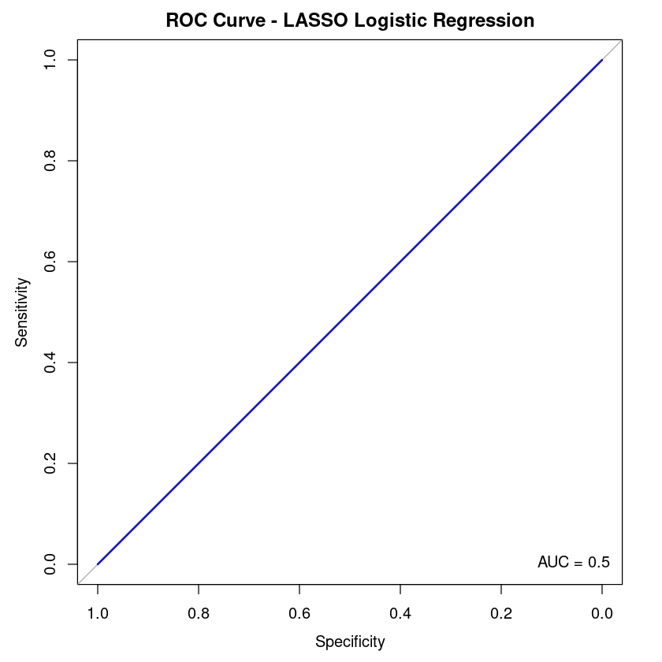

```r
#Lasso and elasticnet
#glmnet

#Option: data scaling

#Lasso  ,  alpha = 1
#The tuning parameter λ controls the overall strength of the penalty.
#family="gaussian"   == > lm
lambda.value = 0.5


#Prepare data matrices for glmnet
X.train <- as.matrix(train.dat[, 1:60])
X.test  <- as.matrix(test.dat[, 1:60])

# Response: convert factor to numeric 0/1 (M = 1, R = 0)
y.train <- ifelse(train.dat$Class == "M", 1, 0)
y.test  <- ifelse(test.dat$Class == "M", 1, 0)


# lambda = 0.5 (example fixed value)
#LASSO logistic regression (alpha = 1)
lambda.value <- 0.5
lasso.fit <- glmnet(
  X.train, y.train,
  family = "binomial",
  alpha = 1,
  lambda = lambda.value
)

# Predicted probabilities on the test set
pred.prob <- predict(lasso.fit, newx = X.test, type = "response")

# threshold = 0.5
pred.class <- ifelse(pred.prob >= 0.5, "M", "R")
pred.class <- factor(pred.class, levels = c("R", "M"))

confusionMatrix(pred.class, test.dat$Class)

roc.obj <- roc(y.test, as.vector(pred.prob))
auc <- auc(roc.obj)
auc

# Plot ROC curve
plot(
  roc.obj,
  col = "blue",
  lwd = 2,
  main = "ROC Curve - LASSO Logistic Regression"
)
legend("bottomright", legend = paste("AUC =", round(auc_value, 3)), bty = "n")
```

```r
# LASSO logistic regression
lasso.fit = train(
  Class ~ .,
  data = train.dat,
  method = "glmnet",
  family = "binomial",
  trControl = trainControl(method = "cv", number = 5),

  # alpha = 1 → LASSO
  tuneGrid = expand.grid(
    alpha = 1,
    lambda = seq(0.0001, 1, length = 50)
  )
)


pred.class = predict(lasso.fit, newdata = test.dat, type = "raw")

pred.prob = predict(lasso.fit, newdata = test.dat, type = "prob")[, "M"]

confusionMatrix(pred.class, test.dat$Class)
```

1. 0.747911409366142

2. 0.843084993054382

3. 0.414726122472108

4. 0.554406811854658

5. 0.350000343228426

6. 0.401829404315775

```
Confusion Matrix and Statistics

          Reference
Prediction  M  R
         M 22 11
         R  5 13

               Accuracy : 0.6863
                 95% CI : (0.5411, 0.8089)
    No Information Rate : 0.5294
    P-Value [Acc > NIR] : 0.01674

                  Kappa : 0.3615

 Mcnemar's Test P-Value : 0.21130

            Sensitivity : 0.8148
            Specificity : 0.5417
         Pos Pred Value : 0.6667
         Neg Pred Value : 0.7222
             Prevalence : 0.5294
         Detection Rate : 0.4314
   Detection Prevalence : 0.6471
      Balanced Accuracy : 0.6782

       'Positive' Class : M
```

```r
library(pROC)

roc.obj = roc(test.dat$Class, pred.prob, levels = c("R","M"), direction = "<")
```

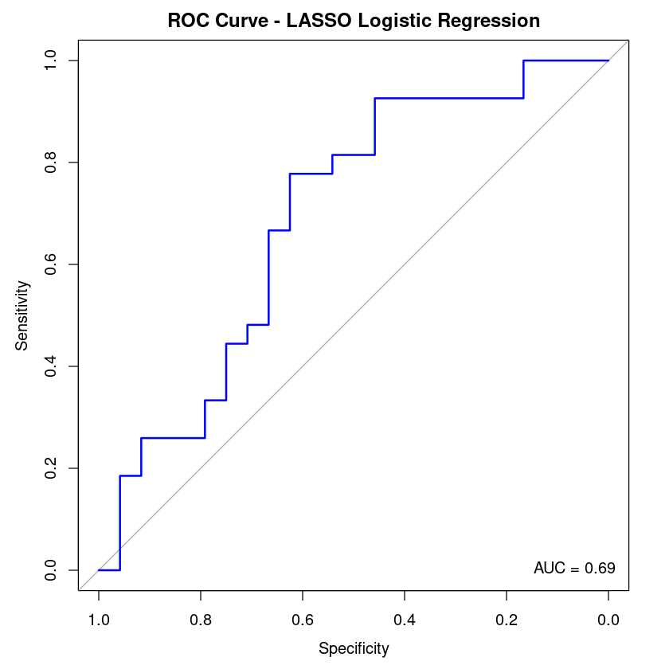

```r
# Plot ROC curve
plot(
  roc.obj,
  col = "blue",         # line color
  lwd = 2,              # line width
  main = "ROC Curve - LASSO Logistic Regression"
)

# Add AUC to the plot
auc_value <- auc(roc.obj)
legend("bottomright", legend = paste("AUC =", round(auc_value, 3)), bty = "n")
```

```r
library(tidyverse)
library(neuralnet)
```

```r
#Transformed data after scaling
#The class
y <- Sonar$Class  # original factor class

Sonar.dat <- Sonar[, -61] %>% mutate_all(scale)
Sonar.dat$Class <- y
Sonar.dat$y01 <- ifelse(Sonar.dat$Class == "M", 1, 0)

# ----------------------------
# For neural network: predictors only
#setdiff(names(train.dat), c("Class")): Removes "Class" from the list of column names.
train0.dat = train.dat [, -61]
test0.dat = test.dat[, -61]
```

```r
set.seed(252)

train0.dat = train.dat
train0.dat$y01 = ifelse(train.dat$Class == "M", 1, 0)
train0.dat$Class = NULL  # remove original factor

test0.dat = test.dat
y.test = ifelse(test.dat$Class == "M", 1, 0)  # keep for ROC/AUC

# hidden layers: 6 and 3 neurons
nn.fit <- neuralnet(
  formula = y01 ~ .,
  data = train0.dat,
  hidden = c(6, 3),
  act.fct = "logistic",
  linear.output = FALSE,
  stepmax = 1e6,
  lifesign = "minimal",
  rep = 1
)
```

```
hidden: 6, 3    thresh: 0.01    rep: 1/1    steps:
    187
	error: 1.51724
	time: 0.05 secs
```

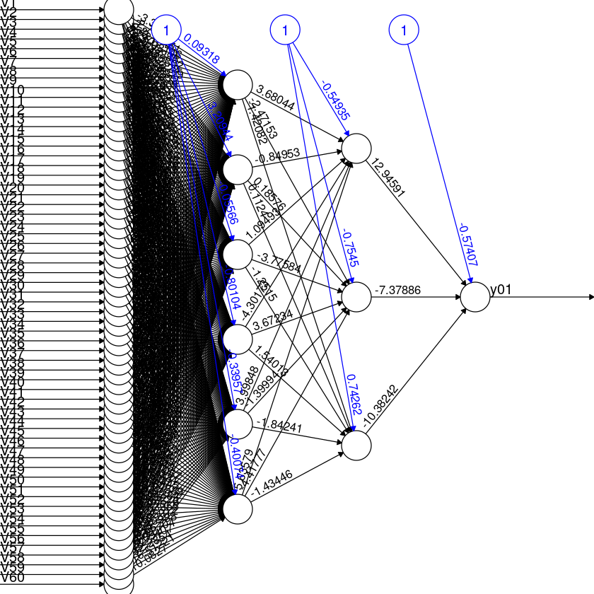

```r
plot(
  nn.fit,
  rep = "best"      # if multiple repetitions, show the best one
)
```

```r
#Predict class probabilities on TEST (prob of positive "M")
nn.pred = as.numeric(predict(nn.fit, test0.dat))  #$net.result[, 1]
#nn.pred
#p.prob.nn = as.numeric(nn.pred)  # probability for "M"
```

[output not shown]

0.799382716049383

[figure not shown]

```r
# Predicted classes (threshold = 0.5)
pred.class <- ifelse(nn.pred >= 0.5, "M", "R")
pred.class <- factor(pred.class, levels = c("R", "M"))


# Confusion Matrix
conf.mat <- confusionMatrix(pred.class, test.dat$Class)
print(conf.mat)

#ROC curve and AUC
# Numeric response for ROC
y.test <- ifelse(test.dat$Class == "M", 1, 0)

roc.obj <- roc(y.test, nn.pred)
auc <- auc(roc.obj)
auc

plot(
  roc.obj,
  col = "red",
  lwd = 2,
  main = "ROC Curve - Neural Network"
)
legend("bottomright", legend = paste("AUC =", round(auc_value, 3)), bty = "n")
```

# Chapter 12: Logistic Regression

Classification problems are similar to regression problems, with the key distinction that the response variable takes on only a **small number of discrete categories**. We begin with **binary classification**, where the response variable $Y$ takes values $0$ or $1$. (Most concepts discussed here extend naturally to multi-class classification.)

Let $$ p(x) = P(Y = 1 \mid X = x) $$ denote the probability that the outcome equals 1, given the predictors $X = (X_1, \ldots, X_p)$.

## Logistic Regression Model

Logistic regression models the **log-odds** (logit) of $Y = 1$ as a linear function of the predictors:

$$ \log\left( \frac{p(x)}{1 - p(x)} \right) = \beta_0 + \beta_1 X_1 + \cdots + \beta_p X_p. $$

The **odds** are defined as $$ \text{odds} = \frac{p(x)}{1 - p(x)}. $$

Exponentiating both sides gives $$ \frac{p(x)}{1 - p(x)} = \exp(\beta_0 + \beta_1 X_1 + \cdots + \beta_p X_p), $$ and solving for $p(x)$ yields the **logistic (sigmoid) function**:

$$ p(x) = \frac{\exp(\beta_0 + \beta_1 X_1 + \cdots + \beta_p X_p)} {1 + \exp(\beta_0 + \beta_1 X_1 + \cdots + \beta_p X_p)}. $$

## Classification Thresholds

A logistic regression model outputs a probability $\hat{p}(x)$ for class 1. To convert this probability into a class label, we apply a threshold:

- Predict class 1 if $\hat{p}(x) \ge \tau$
- Predict class 0 if $\hat{p}(x) < \tau$

The standard choice is $\tau = 0.5$, but the optimal threshold often differs in applications such as:

- Medical diagnosis
- Risk assessment
- Fraud detection

The threshold affects sensitivity and specificity and can be tuned using ROC curves or cost-based criteria.

## Logistic Regression Using `caret` in R

```
library(caret)

default_glm_mod <- train(
  form = default ~ .,
  data = default_trn,
  trControl = trainControl(method = "cv", number = 5),
  method = "glm",
  family = "binomial"
)

# View cross-validated results
default_glm_mod$results

# View the fitted model
default_glm_mod$finalModel
```